# Pump It Up. Data Mining and Machine Learning

## Manuel Guerrero Garzón

### Accuracy: 81.6 %

# Carga de las funciones

```python
# Ejecutamos librerías necesarias

from datetime import datetime

import re

import pandas as pd
import numpy as np

import seaborn as sns
import matplotlib.pyplot as plt

import pycaret
from pycaret.classification import *

from sklearn.preprocessing import LabelEncoder

# Modelos Selección.
from sklearn.model_selection import train_test_split
from sklearn.model_selection import cross_val_score
from sklearn.model_selection import GridSearchCV, StratifiedKFold

# Modelos.
from sklearn.linear_model import LogisticRegression
from sklearn.tree import DecisionTreeClassifier
from sklearn.ensemble import RandomForestClassifier
from sklearn.svm import LinearSVC
from xgboost import XGBClassifier
from sklearn.naive_bayes import GaussianNB
from sklearn.ensemble import AdaBoostClassifier
from sklearn.linear_model import LassoCV
from sklearn.linear_model import RidgeClassifierCV
from sklearn.svm import SVC
from sklearn.model_selection import RepeatedStratifiedKFold


from sklearn.ensemble import ExtraTreesClassifier, GradientBoostingClassifier
from sklearn.linear_model import RidgeClassifier
from sklearn.discriminant_analysis import LinearDiscriminantAnalysis


# Preprocesado.
from sklearn.preprocessing import MinMaxScaler
from sklearn.preprocessing import scale

from imblearn.over_sampling import SMOTE
import pickle
# Métricas.
from sklearn.metrics import classification_report
from sklearn.metrics import accuracy_score, auc, confusion_matrix, f1_score, precision_score, recall_score, roc_curve, classification_report

import feature_engine.imputation as fe_imp
import sklearn.impute as skl_imp
```

# Definición de funciones

```python
def histogram_boxplot(data, xlabel = None, title = None, font_scale=2, figsize=(9,8), bins = None):
    # Definir tamaño letra
    sns.set(font_scale=font_scale)
    # Crear ventana para los subgráficos
    f2, (ax_box2, ax_hist2) = plt.subplots(2, sharex=True, gridspec_kw={"height_ratios": (.15, .85)}, figsize=figsize)
    # Crear boxplot
    sns.boxplot(x=data, ax=ax_box2)
    # Crear histograma
    sns.histplot(x=data, ax=ax_hist2, bins=bins) if bins else sns.histplot(x=data, ax=ax_hist2)
    # Pintar una línea con la media
    ax_hist2.axvline(np.mean(data),color='g',linestyle='-')
    # Pintar una línea con la mediana
    ax_hist2.axvline(np.median(data),color='y',linestyle='--')
    # Asignar título y nombre de eje si tal
    if xlabel: ax_hist2.set(xlabel=xlabel)
    if title: ax_box2.set(title=title, xlabel="")
    # Mostrar gráfico
    plt.show()

def rskf_comparison(models, X_train, y_train):

    results = []
    names = []

    for k, v in models.items():

        rskf = RepeatedStratifiedKFold(n_splits=10, n_repeats=3, random_state=1234)
        cv_scores = cross_val_score(v.fit(X_train, y_train), X_train, y_train, scoring='accuracy', cv=rskf, n_jobs=-1)

        results.append(cv_scores)
        names.append(k)

        print(k)
        print('CV AUC: %.5f +/- %.5f' % (np.mean(cv_scores), np.std(cv_scores)))
        print('-------------------------')


    return(results, names)

def confusion_matrix_plotter (y_test,y_pred):
  fig, ax = plt.subplots(figsize=(8,5))
  data = confusion_matrix(y_test, y_pred)
  df_cm = pd.DataFrame(data, columns=np.unique(y_test), index = np.unique(y_test))
  ax = sns.heatmap(df_cm, cmap='Blues', fmt='g' ,annot=True,annot_kws={"size": 14})
  ax.set_xlabel("Predicted")
  ax.set_ylabel ("Actual")
  ax.set_xticklabels(ax.get_xticklabels(), rotation=45)
  ax.set_yticklabels(ax.get_xticklabels(), rotation=0)


def feature_importances (model, title):
  features= X_train.columns
  importances = np.round(model.feature_importances_,3)
  indices = np.argsort(importances)
  num_features = len(features)
  fig, ax = plt.subplots(figsize=(10,10))
  plt.barh(range(num_features), importances[indices[-num_features:]],  align='center', color =  '#66c2a5')
  plt.yticks(range(num_features), [features[i] for i in indices[-num_features:]])
  plt.xlabel('Relative Importance')
  plt.title('Feature Importance'+ title)
plt.show()
```

## Lectura y primera impresión de los datos

Realizamos la lectura de los conjuntos de datos. La variable "labels" contiene la información de nuestra variable objetivo, la que queremos predecir. Los otros dos conjuntos de datos, "values" y "test", tienen información de las variables predictoras, para el entrenamiento y el testeo.

Veamos nuestra vairable objetivo que estructura tiene.

```python
labels = pd.read_csv('/Users/manuelguerrero/Desktop/Machine Learning/Tarea /Training set labels.csv')
values = pd.read_csv('/Users/manuelguerrero/Desktop/Machine Learning/Tarea /Training set values.csv')
test = pd.read_csv('/Users/manuelguerrero/Desktop/Machine Learning/Tarea /Test set values.csv')
labels.head()
```

|  | id | status_group |
| --- | --- | --- |
| 0 | 69572 | functional |
| 1 | 8776 | functional |
| 2 | 34310 | functional |
| 3 | 67743 | non functional |
| 4 | 19728 | functional |

La variable "status_group" es la variable objetivo, donde tendremos que predecir una serie de bombas de agua que toman por valores "functional", "non functional" y "functional needs repair".

Observamos también la siguiente cantidad de valores que tiene la variable.

```python
labels.status_group.value_counts()
```

```
functional                 32259
non functional             22824
functional needs repair     4317
Name: status_group, dtype: int64
```

Vemos que hay un desbalanceo de datos para el valor "functional needs repair", que es un problema para nuestro modelo. Además, nuestro objetivo será obtener el mejor accuracy del modelo.

Realizamos ahora la unión del conjunto de entrenamiento con la variable objetivo. Además, vamos a crear una nueva variable llamada "tr-tst" para poder diferenciar que registros pertenecen al entrenamiento y al test. Seguidamente, concatenaremos todos los registros en un solo conjunto de datos llamado data.

En los valores de la variable "tr-tst", será valor 0 cuando pertenezca al conjunto entrenamiento, 1 para el test.

Por otro lado, se muestra la información de data.

```python
dt = pd.merge(values, labels, on = 'id', how = 'left')
dt['tr-tst'] = 0
test['tr-tst'] = 1
data = pd.concat([dt, test], sort = False, ignore_index = True)
data.head()
```

|  | id | amount_tsh | date_recorded | funder | gps_height | installer | longitude | latitude | wpt_name | num_private | ... | quality_group | quantity | quantity_group | source | source_type | source_class | waterpoint_type | waterpoint_type_group | status_group | tr-tst |
| --- | --- | --- | --- | --- | --- | --- | --- | --- | --- | --- | --- | --- | --- | --- | --- | --- | --- | --- | --- | --- | --- |
| 0 | 69572 | 6000.0 | 2011-03-14 | Roman | 1390 | Roman | 34.938093 | -9.856322 | none | 0 | ... | good | enough | enough | spring | spring | groundwater | communal standpipe | communal standpipe | functional | 0 |
| 1 | 8776 | 0.0 | 2013-03-06 | Grumeti | 1399 | GRUMETI | 34.698766 | -2.147466 | Zahanati | 0 | ... | good | insufficient | insufficient | rainwater harvesting | rainwater harvesting | surface | communal standpipe | communal standpipe | functional | 0 |
| 2 | 34310 | 25.0 | 2013-02-25 | Lottery Club | 686 | World vision | 37.460664 | -3.821329 | Kwa Mahundi | 0 | ... | good | enough | enough | dam | dam | surface | communal standpipe multiple | communal standpipe | functional | 0 |
| 3 | 67743 | 0.0 | 2013-01-28 | Unicef | 263 | UNICEF | 38.486161 | -11.155298 | Zahanati Ya Nanyumbu | 0 | ... | good | dry | dry | machine dbh | borehole | groundwater | communal standpipe multiple | communal standpipe | non functional | 0 |
| 4 | 19728 | 0.0 | 2011-07-13 | Action In A | 0 | Artisan | 31.130847 | -1.825359 | Shuleni | 0 | ... | good | seasonal | seasonal | rainwater harvesting | rainwater harvesting | surface | communal standpipe | communal standpipe | functional | 0 |

5 rows × 42 columns

Vamos a ver la información de los datos que ha interpretado python.

```python
data.info()
```

```
<class 'pandas.core.frame.DataFrame'>
RangeIndex: 74250 entries, 0 to 74249
Data columns (total 42 columns):
 #   Column                 Non-Null Count  Dtype
---  ------                 --------------  -----
 0   id                     74250 non-null  int64
 1   amount_tsh             74250 non-null  float64
 2   date_recorded          74250 non-null  object
 3   funder                 69746 non-null  object
 4   gps_height             74250 non-null  int64
 5   installer              69718 non-null  object
 6   longitude              74250 non-null  float64
 7   latitude               74250 non-null  float64
 8   wpt_name               74250 non-null  object
 9   num_private            74250 non-null  int64
```

[output cut: 34 more lines]

Donde primeramente, vemos 39 variables predictoras más la variable objetivo (no contamos la variable tr-tst pues es una mera variable orientativa de los conjuntos de datos). Son bastantes, donde analizaremos a futuro si eliminaremos algunas debido a su gran aparienza en su nombre y por la descripción de las mismas:

- amount_tsh - Carga estática total (cantidad de agua disponible para el punto de agua)
- date_recorded: la fecha en que se ingresó la fila
- funder - Quién financió el pozo
- gps_height - Altitud del pozo
- installer - Organización que instaló el pozo
- longitude - coordenada GPS
- latitude - coordenada GPS
- wpt_name - Nombre del punto de agua si lo hay
- num_privado -
- basin - Cuenca hidrográfica geográfica
- subvillage - Ubicación geográfica
- region - Ubicación geográfica
- region_code - Ubicación geográfica (codificada)
- district_code - Ubicación geográfica (codificada)
- lga - Ubicación geográfica
- ward - ubicación geográfica
- population - Población alrededor del pozo
- public_meeting - Verdadero/Falso
- record_by - Grupo ingresando esta fila de datos
- scheme_management - Quién opera el punto de agua
- scheme_name - Quién opera el punto de agua
- permit - Si el punto de agua está permitido
- construction_year - Año en que se construyó el punto de agua
- extract_type: el tipo de extracción que utiliza el punto de agua
- extract_type_group: el tipo de extracción que utiliza el punto de agua
- extract_type_class: el tipo de extracción que utiliza el punto de agua
- management - Cómo se gestiona el punto de agua
- management_group - Cómo se gestiona el punto de agua
- payment - Lo que cuesta el agua
- paymente_type - Cuanto cuesta el agua
- water_quality - La calidad del agua
- quality_group - La calidad del agua
- quantity - La cantidad de agua
- quantity_group - La cantidad de agua
- source - La fuente del agua
- source_type - La fuente del agua
- source_class - La fuente del agua
- waterpoint_type - El tipo de punto de agua
- waterpoint_type_group - El tipo de punto de agua

Además, tendremos que realizar una depuración a los datos, donde tendremos que tratar con valores mal codificados, valores nulos, outliers, etc..

Antes de nada, ayudándonos del modulo pycaret, veamos que accuracy obtenemos de los datos y así hacernos una idea de cuánto de bueno/malos es nuestro modelo. Lo lanzamos sobre los datos de entrenamiento, "values" y "labels", que es el dataframe "dt" que hemos creado.

El código que se realiza de pycaret puede encontrarse al final del notebook, debido a que tarda un rato en terminar los cálculos (en mi ordenador tarde sobre 30-35 mins).

Una vez terminado, observamos que los cuatro mejores modelos con accuracy son los siguientes:

- **Extra Trees Classifier: 0.7601**
- **Ridge Classifier: 0.7599**
- **Linear Discriminant Analysis: 0.7582**
- **Random Forest Classifier: 0.7184**

No está mal para empezar obteniendo ese accuracy en los modelos. En principio, mejoraremos esa métrica usando los cuatros modelos dichos anteriormente.

## Reporte descriptivo de los datos

Vamos a obtener los descriptivos de todas las variables que tenemos en nuestro conjunto de datos, donde obtendremos la media, varianza, número de registros, frecuencia, etc..

```python
data.describe()
```

|  | id | amount_tsh | gps_height | longitude | latitude | num_private | region_code | district_code | population | construction_year | tr-tst |
| --- | --- | --- | --- | --- | --- | --- | --- | --- | --- | --- | --- |
| count | 74250.000000 | 74250.000000 | 74250.000000 | 74250.000000 | 7.425000e+04 | 74250.000000 | 74250.000000 | 74250.000000 | 74250.000000 | 74250.000000 | 74250.000000 |
| mean | 37124.500000 | 318.685704 | 665.667313 | 34.074262 | -5.701771e+00 | 0.462330 | 15.265414 | 5.629077 | 180.750828 | 1298.463650 | 0.200000 |
| std | 21434.273081 | 2906.762364 | 692.761033 | 6.572519 | 2.944969e+00 | 11.537879 | 17.508907 | 9.641636 | 471.086120 | 952.349375 | 0.400003 |
| min | 0.000000 | 0.000000 | -90.000000 | 0.000000 | -1.164944e+01 | 0.000000 | 1.000000 | 0.000000 | 0.000000 | 0.000000 | 0.000000 |
| 25% | 18562.250000 | 0.000000 | 0.000000 | 33.086819 | -8.525675e+00 | 0.000000 | 5.000000 | 2.000000 | 0.000000 | 0.000000 | 0.000000 |
| 50% | 37124.500000 | 0.000000 | 364.000000 | 34.907475 | -5.026540e+00 | 0.000000 | 12.000000 | 3.000000 | 25.000000 | 1986.000000 | 0.000000 |
| 75% | 55686.750000 | 20.000000 | 1317.000000 | 37.181685 | -3.325058e+00 | 0.000000 | 17.000000 | 5.000000 | 215.000000 | 2004.000000 | 0.000000 |
| max | 74249.000000 | 350000.000000 | 2777.000000 | 40.345193 | -2.000000e-08 | 1776.000000 | 99.000000 | 80.000000 | 30500.000000 | 2013.000000 | 1.000000 |

```python
data.describe(exclude = np.number)
```

|  | date_recorded | funder | installer | wpt_name | basin | subvillage | region | lga | ward | public_meeting | ... | water_quality | quality_group | quantity | quantity_group | source | source_type | source_class | waterpoint_type | waterpoint_type_group | status_group |
| --- | --- | --- | --- | --- | --- | --- | --- | --- | --- | --- | --- | --- | --- | --- | --- | --- | --- | --- | --- | --- | --- |
| count | 74250 | 69746 | 69718 | 74250 | 74250 | 73780 | 74250 | 74250 | 74250 | 70095 | ... | 74250 | 74250 | 74250 | 74250 | 74250 | 74250 | 74250 | 74250 | 74250 | 59400 |
| unique | 369 | 2140 | 2410 | 45684 | 9 | 21425 | 21 | 125 | 2098 | 2 | ... | 8 | 6 | 5 | 5 | 10 | 7 | 3 | 7 | 6 | 3 |
| top | 2011-03-17 | Government Of Tanzania | DWE | none | Lake Victoria | Shuleni | Iringa | Njombe | Igosi | True | ... | soft | good | enough | enough | spring | spring | groundwater | communal standpipe | communal standpipe | functional |
| freq | 695 | 11299 | 21751 | 4440 | 12871 | 646 | 6599 | 3128 | 386 | 63749 | ... | 63505 | 63505 | 41522 | 41522 | 21216 | 21216 | 57286 | 35628 | 43239 | 32259 |

4 rows × 31 columns

```python
data.status_group.describe()
```

```
count          59400
unique             3
top       functional
freq           32259
Name: status_group, dtype: object
```

Observamos que las variables numéricas deben de ser tratadas, pues tienen distribuciones un tanto extrañas. Podemos fijarmos por ejemplo en la variable "amount_tsh", donde el cuartil 3, 75%, tiene valor 20 cuando el máximo es de 350000. De la misma manera ocurre con "construction_year", que son el año de construcción de la bomba de agua, que tiene como mínimo un valor 0, siendo esto no posible que una bomba de agua sea construida en ese año.

Esto hace pensar que haya más valores 0s en nuestro conjunto de datos que no sean acordes para las variables en estudio.

De la misma manera para las variables categóricas, vemos que hay variables como "funder" o "ward" que tiene una gran cantidad de valores distintos (fijarse en la fila "unique"). Esto genera un problema a la hora de contruir y predecir.

También se observa que hay una gran cantidad de valores nulos en las variables donde tendremos que realizar imputaciones. Primeramente realizaremos imputaciones a través de la media y la moda.

Vamos a realizar la conversión de todas las variables object a category para una mejor interpretabilidad.

```python
listaCat = data.select_dtypes(include=['object','category']).columns

for col in listaCat:
    data[col] = data[col].astype('category')
```

Comprobamos que ha realizado bien la conversión

```python
data.info()
```

```
<class 'pandas.core.frame.DataFrame'>
RangeIndex: 74250 entries, 0 to 74249
Data columns (total 42 columns):
 #   Column                 Non-Null Count  Dtype
---  ------                 --------------  -----
 0   id                     74250 non-null  int64
 1   amount_tsh             74250 non-null  float64
 2   date_recorded          74250 non-null  category
 3   funder                 69746 non-null  category
 4   gps_height             74250 non-null  int64
 5   installer              69718 non-null  category
 6   longitude              74250 non-null  float64
 7   latitude               74250 non-null  float64
 8   wpt_name               74250 non-null  category
 9   num_private            74250 non-null  int64
```

[output cut: 34 more lines]

Observamos que las variables 'region_code' y 'distict_code', son variables categóricas, por definición de la misma. Son códigos de ubicaciones.

Realizamos la conversión a categóricas a mano.

```python
data['region_code'] = data['region_code'].astype('category')
data['district_code'] = data['district_code'].astype('category')
```

Comprobamos que todas están correctamente:

```python
data.info()
```

```
<class 'pandas.core.frame.DataFrame'>
RangeIndex: 74250 entries, 0 to 74249
Data columns (total 42 columns):
 #   Column                 Non-Null Count  Dtype
---  ------                 --------------  -----
 0   id                     74250 non-null  int64
 1   amount_tsh             74250 non-null  float64
 2   date_recorded          74250 non-null  category
 3   funder                 69746 non-null  category
 4   gps_height             74250 non-null  int64
 5   installer              69718 non-null  category
 6   longitude              74250 non-null  float64
 7   latitude               74250 non-null  float64
 8   wpt_name               74250 non-null  category
 9   num_private            74250 non-null  int64
```

[output cut: 34 more lines]

La dimensión de nuestro dataframe es la siguiente

```python
dim = data.shape

training = data[data['tr-tst'] == 0].shape
test = data[data['tr-tst'] == 1].shape

print("En el dataset de data hay",str(dim[0]) + " filas y " + str(dim[1] - 1)  + " columnas.")

print(f'Para el conjunto entrenamiento tenemmos {training[0]} filas y {training[1]-1} columnas.')
print(f'Para el conjunto test tenemmos {test[0]} filas y {test[1]-1} columnas.')


del dim, training, test
```

```
En el dataset de data hay 74250 filas y 41 columnas.
Para el conjunto entrenamiento tenemmos 59400 filas y 41 columnas.
Para el conjunto test tenemmos 14850 filas y 41 columnas.
```

Veamos la cantidad de valores únicos que tenemos en nuestro conjunto de datos

```python
data.nunique()
```

```
id                       74250
amount_tsh                 102
date_recorded              369
funder                    2140
gps_height                2456
installer                 2410
longitude                71870
latitude                 71869
wpt_name                 45684
num_private                 68
basin                        9
subvillage               21425
region                      21
region_code                 27
district_code               20
lga                        125
ward                      2098
population                1128
public_meeting               2
recorded_by                  1
scheme_management           12
scheme_name               2868
permit                       2
construction_year           55
extraction_type             18
extraction_type_group       13
extraction_type_class        7
management                  12
management_group             5
payment                      7
payment_type                 7
water_quality                8
quality_group                6
quantity                     5
quantity_group               5
source                      10
source_type                  7
source_class                 3
waterpoint_type              7
waterpoint_type_group        6
status_group                 3
tr-tst                       2
dtype: int64
```

Vemos que hay variables categóricas con funder o installer que tienen muchos valores distintos. Esto es un problema para la predicción del modelo. Intentaremos reducir las categorías y estableceremos en cada categoría, valores enteros para una mejor interpretrabilidad en el modelo.

Observamos también casos de categóricas como 'funder' o 'installer' donde tiene muchas categorías, del cual es un problema. Además, la variable 'recorded_by' tiene un único valor y por ello no es importante para predecir los datos.

## Preprocesado de los datos

En esta sección vamos a realizar una depuración de los datos, donde tendremos que comprobar los siguiente puntos:

- **Valores fuera de rango**. Comprobar las limitaciones de las variables, por ejemplo, los valores como 0 en "construction_year"
- **Outliers**. Gracias a la función que hemos definido al principio del todo, veremos como podemos tratar dichos datos, si los eliminamos, pasamos a NANs o aplicamos winsor.
- **Missings**. Incidencia y tratamiento (Eliminar, imputación simple por media, mediana, aleatorio, imputación por modelos) Vamos a realizar primeramente una imputación mediante la media para las numéricas y moda para categóricas.

Comenzamos, antes de nada, transformando la variable "date_recorded" en las variables Año, Mes y Dia; par así obtener una mejor interpretabilidad de estos datos de fecha. Además, vamos a reemplazar los valores categóricos como números, es decir, Monday como 1, Tuesday como 2, etc..

```python
data['date_recorded'] = pd.to_datetime(data['date_recorded'])

# Mejor interpretabilidad de las variables de tiempo FE

data['Año'] = data.date_recorded.apply(lambda x: int(x.year))

# Month:
data["Mes"] = data.date_recorded.apply(lambda x: x.strftime("%B"))

# Lo mismo con día de la semana.
data["Dia"] = data.date_recorded.apply(lambda x: x.strftime("%A"))

# Se elimina la variable original pues ya está convertida a numérica.
data.drop(columns = "date_recorded", inplace = True)


data.Mes.replace(('January','February','March','April','May','June','July','August','September','October','November','December'),
                      (1,2,3,4,5,6,7,8,9,10,11,12),inplace=True)

data.Dia.replace(('Monday','Tuesday','Wednesday','Thursday','Friday','Saturday','Sunday'),
                      (1,2,3,4,5,6,7),inplace=True)


listaNum = data.select_dtypes(exclude=['object','category']).columns
listaCat = data.columns[data.dtypes == 'category'].to_list()
```

```python
data.info()
```

```
<class 'pandas.core.frame.DataFrame'>
RangeIndex: 74250 entries, 0 to 74249
Data columns (total 44 columns):
 #   Column                 Non-Null Count  Dtype
---  ------                 --------------  -----
 0   id                     74250 non-null  int64
 1   amount_tsh             74250 non-null  float64
 2   funder                 69746 non-null  category
 3   gps_height             74250 non-null  int64
 4   installer              69718 non-null  category
 5   longitude              74250 non-null  float64
 6   latitude               74250 non-null  float64
 7   wpt_name               74250 non-null  category
 8   num_private            74250 non-null  int64
 9   basin                  74250 non-null  category
```

[output cut: 36 more lines]

De momento, las variables de tiempo vamos a dejarla como están, en int64.

Vamos a guardar en un dataframe toda la información que hemos recogido hasta el momento, para las posteriores secciones de mejorar del modelo.

```python
dataFE = data.copy()
```

### Valores fuera de rango de variables numéricas

Vamos a realizar la comprobación de todas las variables numéricas que no cuadren con la definición de la misma. Vamos hacer uso de la función "histogram_boxplot()" para visualizar los datos en un histograma y ver la existencia de esos valores fuera de rango. Se pintan tambien dos líneas, una verde que indica la media de los valores, una amarilla que indica la mediana.

Las variables numéricas son las siguientes:

```python
listaNum
```

```
Index(['id', 'amount_tsh', 'gps_height', 'longitude', 'latitude',
       'num_private', 'population', 'construction_year', 'tr-tst', 'Año',
       'Mes', 'Dia'],
      dtype='object')
```

```python
data.info()
```

```
<class 'pandas.core.frame.DataFrame'>
RangeIndex: 74250 entries, 0 to 74249
Data columns (total 44 columns):
 #   Column                 Non-Null Count  Dtype
---  ------                 --------------  -----
 0   id                     74250 non-null  int64
 1   amount_tsh             74250 non-null  float64
 2   funder                 69746 non-null  category
 3   gps_height             74250 non-null  int64
 4   installer              69718 non-null  category
 5   longitude              74250 non-null  float64
 6   latitude               74250 non-null  float64
 7   wpt_name               74250 non-null  category
 8   num_private            74250 non-null  int64
 9   basin                  74250 non-null  category
```

[output cut: 36 more lines]

### gps_height

[figure not shown]

```python
histogram_boxplot(data['gps_height'], bins = 100, font_scale=1, title="Distribción de construction_year")
```

Basándonos en la información de la variable, que es la altitud del pozo, tenemos que Tanzania es un país que está por encima del nivel del mar (mirando el mapa topográfico de Tanzania: https://es-ar.topographic-map.com/map-b1gkl/Tanzania/?center=-6.94824%2C36.43066&base=4).

Tampoco queda muy claro si la variable está indicando la altitud sobre el nivel del mar o del mismo pozo. Además, si graficamos los puntos con las variables latitude y longitude, para localizar donde se encuentran los ceros:

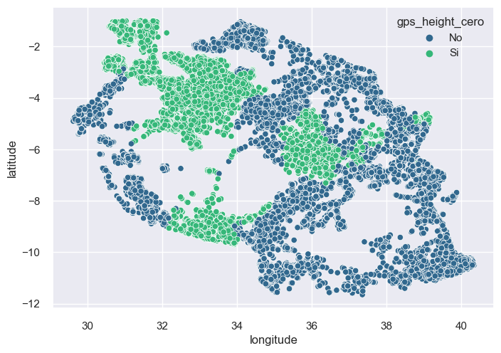

```python
aux = data[data['longitude'] != 0]
aux['gps_height_cero'] = np.where(aux['gps_height'] == 0, "Si", "No")
sns.scatterplot(aux['longitude'], aux['latitude'], hue = aux['gps_height_cero'], palette = 'viridis')

plt.show()
```

Algo que no cuadra con el sistema topográfico ya que son puntos que están en el interior del país, pues Tanzania se encuentra al este de África. Por tanto, se decide pasarlos a NANs e imputarlos respecto a la media.

```python
data.loc[data.gps_height <= 0, 'gps_height'] = np.nan
```

### latitude y longitude

Veamos en esta variable si hay valores que no correpondan. Pintaremos un scatter plot para comprobarlo.

[output not shown]

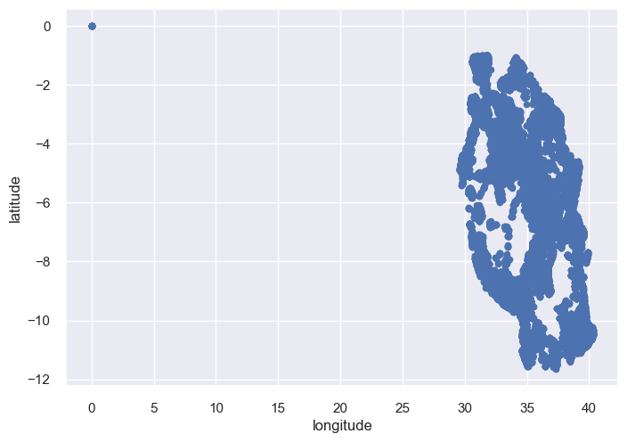

```python
data.plot.scatter(x = 'longitude', y = 'latitude')
```

Donde observamos que hay un valor en el mapa (0,0), es un valor que no corresponde con los demás. Además, buscando información de la latitud y longitud del país, se tiene que es, aproximadamente, 6º S y 35º E. Por tanto, los valores no corresponde con la localización.

Veamos el histograma de longitude:

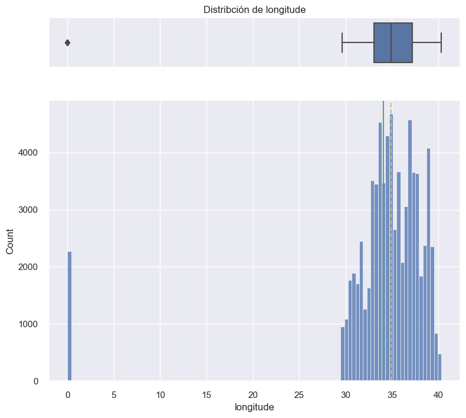

```python
histogram_boxplot(data['longitude'], bins = 100, font_scale=1, title="Distribción de longitude")
```

Donde observamos que sí hay valores que no corresponden con la propia variable. Viendo el dataframe:

```python
data[data['longitude'] == 0].head()
```

|  | id | amount_tsh | funder | gps_height | installer | longitude | latitude | wpt_name | num_private | basin | ... | source | source_type | source_class | waterpoint_type | waterpoint_type_group | status_group | tr-tst | Año | Mes | Dia |
| --- | --- | --- | --- | --- | --- | --- | --- | --- | --- | --- | --- | --- | --- | --- | --- | --- | --- | --- | --- | --- | --- |
| 21 | 6091 | 0.0 | Dwsp | NaN | DWE | 0.0 | -2.000000e-08 | Muungano | 0 | Lake Victoria | ... | shallow well | shallow well | groundwater | hand pump | hand pump | functional | 0 | 2013 | 2 | 7 |
| 53 | 32376 | 0.0 | Government Of Tanzania | NaN | Government | 0.0 | -2.000000e-08 | Polisi | 0 | Lake Victoria | ... | machine dbh | borehole | groundwater | communal standpipe multiple | communal standpipe | non functional | 0 | 2011 | 8 | 1 |
| 168 | 72678 | 0.0 | Wvt | NaN | WVT | 0.0 | -2.000000e-08 | Wvt Tanzania | 0 | Lake Victoria | ... | rainwater harvesting | rainwater harvesting | surface | communal standpipe | communal standpipe | functional | 0 | 2013 | 1 | 3 |
| 177 | 56725 | 0.0 | Netherlands | NaN | DWE | 0.0 | -2.000000e-08 | Kikundi Cha Wakina Mama | 0 | Lake Victoria | ... | shallow well | shallow well | groundwater | other | other | non functional | 0 | 2013 | 1 | 4 |
| 253 | 13042 | 0.0 | Hesawa | NaN | DWE | 0.0 | -2.000000e-08 | Kwakisusi | 0 | Lake Victoria | ... | shallow well | shallow well | groundwater | hand pump | hand pump | functional needs repair | 0 | 2012 | 10 | 1 |

5 rows × 44 columns

Tenemos en el caso de la longitud los valores que son ceros. Vamos a convertirlos a NANs e imputarlos con respecto la media.

```python
data.loc[data.longitude == 0, 'longitude'] = np.nan
```

Para el caso de latitude no tenemos valores fuera de su rango.

```python
data[data['latitude'] == 0].head()
```

|  | id | amount_tsh | funder | gps_height | installer | longitude | latitude | wpt_name | num_private | basin | ... | source | source_type | source_class | waterpoint_type | waterpoint_type_group | status_group | tr-tst | Año | Mes | Dia |
| --- | --- | --- | --- | --- | --- | --- | --- | --- | --- | --- | --- | --- | --- | --- | --- | --- | --- | --- | --- | --- | --- |

0 rows × 44 columns

[output not shown]

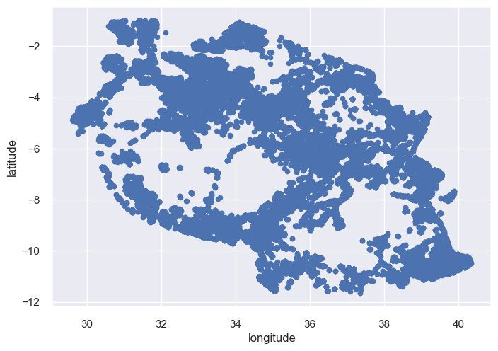

```python
data.plot.scatter('longitude', 'latitude')
```

Ya tiene más sentido este par de variables.

### population

Veamos la variable que sigue la población de Tanzania en el dataframe.

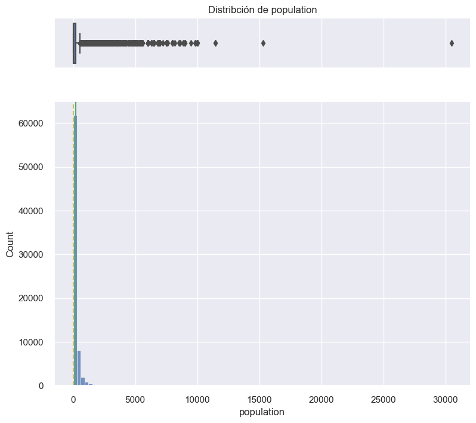

```python
histogram_boxplot(data['population'], bins = 100, font_scale=1, title="Distribción de population")
```

Observamos que la concentración está en valores pequeños de la población, y además, hay muchos outliers para esta variable. Veamos la cantidad de ceros que hay.

```python
data['population'].value_counts()
```

```
0       26834
1        8782
200      2370
150      2328
250      2087
        ...
3236        1
1840        1
1265        1
2652        1
2960        1
Name: population, Length: 1128, dtype: int64
```

En cierta manera, podemos convertir todos estos valores ceros como nans y luego imputarlos con la media. Entiendo que los pozos lo utilizan personas, y como tal, no tiene mucho sentido de considerar que un pozo no sea funcional cuando no hay personas que vivan cerca del mismo.

```python
data.loc[data.population == 0, 'population'] = np.nan
```

```python
data['population'].value_counts()
```

```
1.0       8782
200.0     2370
150.0     2328
250.0     2087
300.0     1842
          ...
3236.0       1
1840.0       1
1265.0       1
2652.0       1
2960.0       1
Name: population, Length: 1127, dtype: int64
```

### construction_year

Por definición de la variable, es el año en el que se contruyó el pozo. Veamos el histograma:

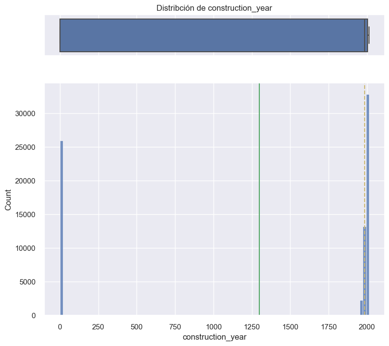

```python
histogram_boxplot(data['construction_year'], bins = 100, font_scale=1, title="Distribción de construction_year")
```

Obviamente, no tiene sentido considerar los años 0, cuando por el histograma se observa que están en torno al 2000. Aparte que no tiene sentido en la vida en la que estamos. Convertimos a NANs todos estos valores. Esta variable la imputaremos con la mediana, pues la media sale en torno a 1250 y pues no tiene mucho sentido considerar ese año de construcción.

```python
data.loc[data.construction_year == 0, 'construction_year'] = np.nan

# Verificamos que no saca filas.
data[data['construction_year'] == 0]
```

|  | id | amount_tsh | funder | gps_height | installer | longitude | latitude | wpt_name | num_private | basin | ... | source | source_type | source_class | waterpoint_type | waterpoint_type_group | status_group | tr-tst | Año | Mes | Dia |
| --- | --- | --- | --- | --- | --- | --- | --- | --- | --- | --- | --- | --- | --- | --- | --- | --- | --- | --- | --- | --- | --- |

0 rows × 44 columns

### amount_tsh

Esta variable es la cantidad de agua disponible para el punto de agua.

[figure not shown]

```python
histogram_boxplot(data['amount_tsh'], bins = 100, font_scale=1, title="Distribción de construction_year")
```

Donde tenemos una gran cantidad de 0 en dicha variable, en especial, unos 52000. Son muchos registros con el mismo valor y que además, debería de haber agua en los pozos, ya que sino a la hora del registro estarían como 'non functional'.

```python
data['amount_tsh'].value_counts()
```

```
0.0         52049
500.0        3874
50.0         3103
1000.0       1858
20.0         1812
            ...
250000.0        1
350000.0        1
5400.0          1
53.0            1
0.5             1
Name: amount_tsh, Length: 102, dtype: int64
```

Y donde vemos que hay como unos 19000 que son funcionales pero no tienen agua. Pero de la misma forma tenemos unos 18000 que son no funcionales. Voy a dejar esta variable como está ya que dicho valor puede servir a la hora de predecir la variable respuesta.

```python
data[data['amount_tsh'] == 0]['status_group'].value_counts()
```

```
functional                 19706
non functional             18885
functional needs repair     3048
Name: status_group, dtype: int64
```

### num_private

Esta variable tiene una gran cantidad de valores ceros. Además, no se nos da una definición de la misma. La descartaremos del modelo, ya que no sé muy bien que función tiene.

```python
data['num_private'].value_counts()
```

```
0      73299
1         94
6         92
5         60
8         58
       ...
136        1
672        1
668        1
698        1
420        1
Name: num_private, Length: 68, dtype: int64
```

### Valores fuera de rango categóricas.

Nos surge la duda, si en las variables categóricas hay valores que no cuadren con las categórías de las variables. Estos son valores tipo: 'Desconocido', 'desconocido', 'unknown' y 'Unknown'. En cierta manera, no vamos a imputarlos como NANs, ya que puede ser una categoría que tenga relación con la variable objetivo y nos de una predicción del mismo.

Además, detectamos que en las variables 'funder' y 'installer' se tiene el valor '0'.

Las variables categóricas son las siguientes:

```python
listaCat
```

```
['funder',
 'installer',
 'wpt_name',
 'basin',
 'subvillage',
 'region',
 'region_code',
 'district_code',
 'lga',
 'ward',
 'public_meeting',
 'recorded_by',
 'scheme_management',
 'scheme_name',
 'permit',
 'extraction_type',
 'extraction_type_group',
 'extraction_type_class',
 'management',
 'management_group',
 'payment',
 'payment_type',
 'water_quality',
 'quality_group',
 'quantity',
 'quantity_group',
 'source',
 'source_type',
 'source_class',
 'waterpoint_type',
 'waterpoint_type_group',
 'status_group']
```

Vamos a sacar todas las variable que hemos comentado anteriormente que tenga los valores comentados.

```python
valores = ['Desconocido', 'desconocido', 'unknown', 'Unknown', '0']
variables = []

for i in range(len(valores)):
    for col in listaCat:
        aux = data[data[col] == valores[i]].shape
        if aux[0] != 0:
            print(f'En la variable {col} está el valor {valores[i]} que no corresponde.')
            variables.append(col)


# Eliminamos duplicados
varFin = []
for var in variables:
    if var not in varFin:
        varFin.append(var)
```

```
En la variable installer está el valor unknown que no corresponde.
En la variable management está el valor unknown que no corresponde.
En la variable management_group está el valor unknown que no corresponde.
En la variable payment está el valor unknown que no corresponde.
En la variable payment_type está el valor unknown que no corresponde.
En la variable water_quality está el valor unknown que no corresponde.
En la variable quality_group está el valor unknown que no corresponde.
En la variable quantity está el valor unknown que no corresponde.
En la variable quantity_group está el valor unknown que no corresponde.
En la variable source está el valor unknown que no corresponde.
En la variable source_class está el valor unknown que no corresponde.
En la variable funder está el valor Unknown que no corresponde.
En la variable installer está el valor Unknown que no corresponde.
En la variable wpt_name está el valor Unknown que no corresponde.
En la variable funder está el valor 0 que no corresponde.
En la variable installer está el valor 0 que no corresponde.
```

Convertimos solo las que tenga '0'.

```python
for var in varFin:
    data.loc[data[var] == '0', var] = np.nan
```

### Outliers

No vamos a realizar un tratamiento de outliers debido a las variables numéricas que estamos estudiando. Por ejemplo, 'population' es la población del lugar, donde aunque haya ciudades con gran número de personas con respecto a otras ciudades, éstas deben de ser estudiadas por igual ya que pueden afectar al final en el modelo.

```python
data[listaNum].head()
```

|  | id | amount_tsh | gps_height | longitude | latitude | num_private | population | construction_year | tr-tst | Año | Mes | Dia |
| --- | --- | --- | --- | --- | --- | --- | --- | --- | --- | --- | --- | --- |
| 0 | 69572 | 6000.0 | 1390.0 | 34.938093 | -9.856322 | 0 | 109.0 | 1999.0 | 0 | 2011 | 3 | 1 |
| 1 | 8776 | 0.0 | 1399.0 | 34.698766 | -2.147466 | 0 | 280.0 | 2010.0 | 0 | 2013 | 3 | 3 |
| 2 | 34310 | 25.0 | 686.0 | 37.460664 | -3.821329 | 0 | 250.0 | 2009.0 | 0 | 2013 | 2 | 1 |
| 3 | 67743 | 0.0 | 263.0 | 38.486161 | -11.155298 | 0 | 58.0 | 1986.0 | 0 | 2013 | 1 | 1 |
| 4 | 19728 | 0.0 | NaN | 31.130847 | -1.825359 | 0 | NaN | NaN | 0 | 2011 | 7 | 3 |

### Missings

Vamos a realizar el tratamiento de missings en nuestro conjunto de datos.

Una opción en las imputaciones, sería eliminar los registros que tienen nans en alguna de sus variables, pero observamos lo siguiente:

```python
data.info()
```

```
<class 'pandas.core.frame.DataFrame'>
RangeIndex: 74250 entries, 0 to 74249
Data columns (total 44 columns):
 #   Column                 Non-Null Count  Dtype
---  ------                 --------------  -----
 0   id                     74250 non-null  int64
 1   amount_tsh             74250 non-null  float64
 2   funder                 68766 non-null  category
 3   gps_height             46720 non-null  float64
 4   installer              68738 non-null  category
 5   longitude              71981 non-null  float64
 6   latitude               74250 non-null  float64
 7   wpt_name               74250 non-null  category
 8   num_private            74250 non-null  int64
 9   basin                  74250 non-null  category
```

[output cut: 36 more lines]

```python
data.dropna().info()
```

```
<class 'pandas.core.frame.DataFrame'>
Int64Index: 19948 entries, 0 to 59396
Data columns (total 44 columns):
 #   Column                 Non-Null Count  Dtype
---  ------                 --------------  -----
 0   id                     19948 non-null  int64
 1   amount_tsh             19948 non-null  float64
 2   funder                 19948 non-null  category
 3   gps_height             19948 non-null  float64
 4   installer              19948 non-null  category
 5   longitude              19948 non-null  float64
 6   latitude               19948 non-null  float64
 7   wpt_name               19948 non-null  category
 8   num_private            19948 non-null  int64
 9   basin                  19948 non-null  category
```

[output cut: 36 more lines]

Veamos cuantos registros tenemos por cada variable, en porcentaje:

```python
nans = round(data.isna().sum()/len(data)*100,2)
nans = nans.sort_values(ascending = False)
nans
```

```
scheme_name              47.49
gps_height               37.08
population               36.14
construction_year        34.98
status_group             20.00
installer                 7.42
funder                    7.39
scheme_management         6.53
public_meeting            5.60
permit                    5.11
longitude                 3.06
subvillage                0.63
payment_type              0.00
water_quality             0.00
quantity                  0.00
quantity_group            0.00
quality_group             0.00
source_class              0.00
source                    0.00
source_type               0.00
management_group          0.00
waterpoint_type           0.00
waterpoint_type_group     0.00
tr-tst                    0.00
Año                       0.00
Mes                       0.00
payment                   0.00
id                        0.00
management                0.00
extraction_type_class     0.00
extraction_type_group     0.00
extraction_type           0.00
amount_tsh                0.00
recorded_by               0.00
ward                      0.00
lga                       0.00
district_code             0.00
region_code               0.00
region                    0.00
basin                     0.00
num_private               0.00
wpt_name                  0.00
latitude                  0.00
Dia                       0.00
dtype: float64
```

Hay gran cantidad de outliers en algunas variables, donde por ejemlo en 'scheme_name' hay cerca del 50% de valores nans. Vamos a considerar ahora mismo el modelo completo con todas las variables.

Realizaremos imputaciones sobre la media y la moda para las numéricas y categóricas, respectivamente.

Antes de nada, tenemos que quitar la variable objetivo, para que no impute sobre los nans que tienen asignado para el conjunto test. Vamos a eliminar como tal toda la variable y luego la uniremos al conjunto de datos.

```python
varObj = data.status_group
imputedData = data.drop('status_group', axis = 1)
```

Definimos las tres imputaciones.

```python
# Moda
imputer_moda = skl_imp.SimpleImputer(strategy='most_frequent', missing_values=np.nan)
# Media
imputer_mean = fe_imp.MeanMedianImputer(imputation_method='mean')
# Mediana
imputer_median = fe_imp.MeanMedianImputer(imputation_method = 'median')
```

Definimos las listas de variables numéricas y categóricas.

```python
imput_cont = imputedData.select_dtypes(include=np.number)
imput_cat = imputedData.select_dtypes(exclude=np.number)

imput_contMediana = pd.DataFrame(imput_cont['construction_year'])
imput_cont.drop('construction_year', axis = 1, inplace = True)
```

Realizamos imputaciones sobre las variables numéricas a partir de la media.

```python
# Media
datos_mean_imputed = imputer_mean.fit(imput_cont).transform(imput_cont)

# Mediana
datos_median_imputed = imputer_median.fit(imput_contMediana).transform(imput_contMediana)
```

Realizamos las imputaciones sobre las variables categóricas a partir de la moda.

```python
imput_moda_imputed = pd.DataFrame(imputer_moda.fit_transform(imput_cat),columns=imput_cat.columns)
```

Unimos los dos conjunto de datos ya imputados y lo guardamos en el dataframe 'data_imputed', para que más adelante podamos utilizar el dataframe 'data' sin ningún problema. Además, introducimos la variable objetivo y comprobamos que sigue teniendo los nans que queremos.

```python
data_imputed = pd.concat([datos_mean_imputed,datos_median_imputed,imput_moda_imputed], axis = 1)
data_imputed['status_group'] = varObj
data_imputed.info()
```

```
<class 'pandas.core.frame.DataFrame'>
RangeIndex: 74250 entries, 0 to 74249
Data columns (total 44 columns):
 #   Column                 Non-Null Count  Dtype
---  ------                 --------------  -----
 0   id                     74250 non-null  int64
 1   amount_tsh             74250 non-null  float64
 2   gps_height             74250 non-null  float64
 3   longitude              74250 non-null  float64
 4   latitude               74250 non-null  float64
 5   num_private            74250 non-null  int64
 6   population             74250 non-null  float64
 7   tr-tst                 74250 non-null  int64
 8   Año                    74250 non-null  int64
 9   Mes                    74250 non-null  int64
```

[output cut: 36 more lines]

Ya tenemos nuestro conjunto de datos listo para entrenar los modelos.

Se observa que después de las imputaciones sobre las variables categóricas, éstas se convierten a tipo 'object', donde realizamos una conversión a 'category'.

```python
listObjec = data_imputed.columns[data_imputed.dtypes == 'object'].tolist()

for col in listObjec:
    data_imputed[col] = data_imputed[col].astype('category')
```

## Conversión de las categorías a numéricas categóricas

En este apartado vamos a tranformar las variables categóricas en variables de tipo entero, que seguirán siendo categorías pero de valor entero para que los modelos que vamos a introducir tengan mejor interpretabilidad de las variables.

Hacemos uso de la función LabelEncoder()

```python
cols = data_imputed.columns[data_imputed.dtypes == 'category'].tolist()

for col in cols:
    le = LabelEncoder()
    data_imputed[col] = le.fit_transform(data_imputed[col])

data_imputed.head()
```

|  | id | amount_tsh | gps_height | longitude | latitude | num_private | population | tr-tst | Año | Mes | ... | water_quality | quality_group | quantity | quantity_group | source | source_type | source_class | waterpoint_type | waterpoint_type_group | status_group |
| --- | --- | --- | --- | --- | --- | --- | --- | --- | --- | --- | --- | --- | --- | --- | --- | --- | --- | --- | --- | --- | --- |
| 0 | 69572 | 6000.0 | 1390.000000 | 34.938093 | -9.856322 | 0 | 109.000000 | 0 | 2011 | 3 | ... | 6 | 2 | 1 | 1 | 8 | 6 | 0 | 1 | 1 | 0 |
| 1 | 8776 | 0.0 | 1399.000000 | 34.698766 | -2.147466 | 0 | 280.000000 | 0 | 2013 | 3 | ... | 6 | 2 | 2 | 2 | 5 | 3 | 1 | 1 | 1 | 0 |
| 2 | 34310 | 25.0 | 686.000000 | 37.460664 | -3.821329 | 0 | 250.000000 | 0 | 2013 | 2 | ... | 6 | 2 | 1 | 1 | 0 | 1 | 1 | 2 | 1 | 0 |
| 3 | 67743 | 0.0 | 263.000000 | 38.486161 | -11.155298 | 0 | 58.000000 | 0 | 2013 | 1 | ... | 6 | 2 | 0 | 0 | 3 | 0 | 0 | 2 | 1 | 2 |
| 4 | 19728 | 0.0 | 1058.722303 | 31.130847 | -1.825359 | 0 | 283.042623 | 0 | 2011 | 7 | ... | 6 | 2 | 3 | 3 | 5 | 3 | 1 | 1 | 1 | 0 |

5 rows × 44 columns

Donde dicha conversión a la variable respuesta se le ha dado los siguiente valores enteros a las categorías:

- 0 -> functional
- 1 -> functional needs repair
- 2 -> non functional

También le habrá dado a los valores NANs de la variable respuesta, con valor 3. Realizaremos su conversión nuevamente.

```python
data_imputed[data_imputed['status_group'] == 3].head()
```

|  | id | amount_tsh | gps_height | longitude | latitude | num_private | population | tr-tst | Año | Mes | ... | water_quality | quality_group | quantity | quantity_group | source | source_type | source_class | waterpoint_type | waterpoint_type_group | status_group |
| --- | --- | --- | --- | --- | --- | --- | --- | --- | --- | --- | --- | --- | --- | --- | --- | --- | --- | --- | --- | --- | --- |
| 59400 | 50785 | 0.0 | 1996.0 | 35.290799 | -4.059696 | 0 | 321.0 | 1 | 2013 | 2 | ... | 6 | 2 | 3 | 3 | 5 | 3 | 1 | 6 | 5 | 3 |
| 59401 | 51630 | 0.0 | 1569.0 | 36.656709 | -3.309214 | 0 | 300.0 | 1 | 2013 | 2 | ... | 6 | 2 | 2 | 2 | 8 | 6 | 0 | 1 | 1 | 3 |
| 59402 | 17168 | 0.0 | 1567.0 | 34.767863 | -5.004344 | 0 | 500.0 | 1 | 2013 | 2 | ... | 6 | 2 | 2 | 2 | 5 | 3 | 1 | 6 | 5 | 3 |
| 59403 | 45559 | 0.0 | 267.0 | 38.058046 | -9.418672 | 0 | 250.0 | 1 | 2013 | 1 | ... | 6 | 2 | 0 | 0 | 7 | 5 | 0 | 6 | 5 | 3 |
| 59404 | 49871 | 500.0 | 1260.0 | 35.006123 | -10.950412 | 0 | 60.0 | 1 | 2013 | 3 | ... | 6 | 2 | 1 | 1 | 8 | 6 | 0 | 1 | 1 | 3 |

5 rows × 44 columns

Además, viendo la información de las variables, vamos a realizar la conversión de flotante a entero de las siguiente variables:

- population
- construction_year

```python
data_imputed['population'] = data_imputed['population'].astype('int64')
data_imputed['construction_year'] = data_imputed['construction_year'].astype('int64')
```

## Construir el dataset train y test. Accuracy de modelos completos.

Antes de nada, tendremos que separar los dos conjuntos de datos de nuestro dataframe, en el training que será el que se introducirá en el modelo para que aprenda, y el test que será donde realizaremos las predicciones y lo meteremos en la página web para ver el accuracy que obtenemos.

```python
training = data_imputed[data_imputed['tr-tst'] == 0].copy()
training.drop('tr-tst', axis = 1, inplace = True)
test = data_imputed[data_imputed['tr-tst'] == 1].copy()
test.drop('tr-tst', axis = 1, inplace = True)
test['status_group'] = np.nan
```

Saquemos los dos conjuntos de datos y observamos que tenmos los datos bien separados.

```python
test.head()
```

|  | id | amount_tsh | gps_height | longitude | latitude | num_private | population | Año | Mes | Dia | ... | water_quality | quality_group | quantity | quantity_group | source | source_type | source_class | waterpoint_type | waterpoint_type_group | status_group |
| --- | --- | --- | --- | --- | --- | --- | --- | --- | --- | --- | --- | --- | --- | --- | --- | --- | --- | --- | --- | --- | --- |
| 59400 | 50785 | 0.0 | 1996.0 | 35.290799 | -4.059696 | 0 | 321 | 2013 | 2 | 1 | ... | 6 | 2 | 3 | 3 | 5 | 3 | 1 | 6 | 5 | NaN |
| 59401 | 51630 | 0.0 | 1569.0 | 36.656709 | -3.309214 | 0 | 300 | 2013 | 2 | 1 | ... | 6 | 2 | 2 | 2 | 8 | 6 | 0 | 1 | 1 | NaN |
| 59402 | 17168 | 0.0 | 1567.0 | 34.767863 | -5.004344 | 0 | 500 | 2013 | 2 | 5 | ... | 6 | 2 | 2 | 2 | 5 | 3 | 1 | 6 | 5 | NaN |
| 59403 | 45559 | 0.0 | 267.0 | 38.058046 | -9.418672 | 0 | 250 | 2013 | 1 | 2 | ... | 6 | 2 | 0 | 0 | 7 | 5 | 0 | 6 | 5 | NaN |
| 59404 | 49871 | 500.0 | 1260.0 | 35.006123 | -10.950412 | 0 | 60 | 2013 | 3 | 3 | ... | 6 | 2 | 1 | 1 | 8 | 6 | 0 | 1 | 1 | NaN |

5 rows × 43 columns

```python
training.head()
```

|  | id | amount_tsh | gps_height | longitude | latitude | num_private | population | Año | Mes | Dia | ... | water_quality | quality_group | quantity | quantity_group | source | source_type | source_class | waterpoint_type | waterpoint_type_group | status_group |
| --- | --- | --- | --- | --- | --- | --- | --- | --- | --- | --- | --- | --- | --- | --- | --- | --- | --- | --- | --- | --- | --- |
| 0 | 69572 | 6000.0 | 1390.000000 | 34.938093 | -9.856322 | 0 | 109 | 2011 | 3 | 1 | ... | 6 | 2 | 1 | 1 | 8 | 6 | 0 | 1 | 1 | 0 |
| 1 | 8776 | 0.0 | 1399.000000 | 34.698766 | -2.147466 | 0 | 280 | 2013 | 3 | 3 | ... | 6 | 2 | 2 | 2 | 5 | 3 | 1 | 1 | 1 | 0 |
| 2 | 34310 | 25.0 | 686.000000 | 37.460664 | -3.821329 | 0 | 250 | 2013 | 2 | 1 | ... | 6 | 2 | 1 | 1 | 0 | 1 | 1 | 2 | 1 | 0 |
| 3 | 67743 | 0.0 | 263.000000 | 38.486161 | -11.155298 | 0 | 58 | 2013 | 1 | 1 | ... | 6 | 2 | 0 | 0 | 3 | 0 | 0 | 2 | 1 | 2 |
| 4 | 19728 | 0.0 | 1058.722303 | 31.130847 | -1.825359 | 0 | 283 | 2011 | 7 | 3 | ... | 6 | 2 | 3 | 3 | 5 | 3 | 1 | 1 | 1 | 0 |

5 rows × 43 columns

Como hemos dicho antes, vamos a realizar una predicción sobre el conjunto entrenamiento de modelo completo sin la variable 'recorde_by' por tener solo un valor.

```python
training.drop('recorded_by', axis = 1, inplace = True)
```

Prodecemos a crear los conjuntos de datos train y test a partir del dataframe training. Realizaremos un muestreo estratificado en función de la variable respuesta para que en los splits sus categorías estén bien representadas. El split a utilizar será un 80/20, training/test, respectivamente.

```python
X_train, X_test, y_train, y_test = train_test_split(training.drop('status_group', axis=1),
                                                     training.status_group,
                                                     test_size = 0.2,
                                                     random_state = 1234,
                                                     stratify = training.status_group)
```

Vamos a realizar una comparación de los siguientes modelos.

- **Extra Trees Classifier**
- **DecisionTreeClassifier**
- **Random Forest Classifier**

##### Random Forest Classifier

```python
model1 = RandomForestClassifier(random_state = 1234).fit(X_train, y_train)
y_pred = model1.predict(X_test)
accuracy_score(y_pred, y_test)
```

[output not shown]

[output cut: 37 more lines]

[output not shown]

##### DecisionTreeClassifier

```python
model2 = DecisionTreeClassifier(random_state = 1234).fit(X_train, y_train)
y_pred = model2.predict(X_test)
accuracy_score(y_pred, y_test)
```

[output not shown]

##### Extra Trees Classifier

```python
model3 = ExtraTreesClassifier(random_state = 1234).fit(X_train, y_train)
y_pred = model3.predict(X_test)
accuracy_score(y_pred, y_test)
```

[output not shown]

```python
models_rcv = {
    "RF": RandomForestClassifier(random_state = 1234)
}

results, names = rskf_comparison(models_rcv, X_train, y_train)
plt.figure(figsize=(10, 6))
comparison = plt.boxplot(results)
plt.xticks(np.arange(1,len(names)+1),names)
plt.show(comparison)
```

[output not shown]

Veamos los scores que ha obtenido.

```python
results
```

Vamos a sacar para este modelo, los accuracy de train y test, así como la matriz de confusión.

```python
#score model
best_model = RandomForestClassifier(random_state = 1234)

#fit and predict
best_model.fit(X_train, y_train)
y_pred = best_model.predict(X_test)
y_pred_train = best_model.predict(X_train)

#print best model scores on test data
print("Accuracy score train: {}".format(accuracy_score(y_train, y_pred_train)))
print("Accuracy score test: {}".format(accuracy_score(y_test, y_pred)))
print()

#print(confusion_matrix(y_test, y_pred))
print(classification_report(y_test, y_pred))

confusion_matrix_plotter(y_test, y_pred)

feature_importances(best_model, " Random forest classifier")
```

[output not shown]

Por otra parte, realizamos la predicción del conjunto test. Creamos un dataset con los 'id' del test.

```python
modelo = pd.DataFrame(test['id'])
modelo.head()
```

```python
test.drop('recorded_by', axis = 1, inplace = True)

modelo_proba = best_model.predict(test.drop('status_group', axis = 1))
modelo_proba = pd.DataFrame(modelo_proba,columns=['status_group'], index = test.index)
modelo_proba.head()
```

Lo guardamos en la predicción del dataframe y realizamos la conversión de los números enteros por los valores que les corresponde, como hemos visto antes con la función LabelEncoder():

- 0 -> functional
- 1 -> functional needs repair
- 2 -> non functional

```python
modelo['status_group'] = modelo_proba['status_group']
```

```python
modelo.loc[modelo.status_group == 0, 'status_group'] = 'functional'
modelo.loc[modelo.status_group == 1, 'status_group'] = 'functional needs repair'
modelo.loc[modelo.status_group == 2, 'status_group'] = 'non functional'
modelo.head()
```

Ya tenemos dicha la predicción. Vamos a guardarlo en un archivo csv para subirlo en la página web drivendata Pump it Up: Data Mining the Water Table, veamos que accuracy obtenemos ahí.

```python
modelo.to_csv('predicción.csv', index = False)
```

Obtenemos un accuracy de: 0.8141.

[figure not shown]

Ahora vamos a intentar mejorar nuestra métrica mejorando el modelo. Primero observemos la importancia de las variables.

```python
feat_importances = pd.DataFrame(classifier.feature_importances_, index=X_train.columns, columns=["Importance"])
feat_importances.sort_values(by='Importance', ascending=False, inplace=True)
feat_importances.plot(kind='bar', figsize=(8,6))
```

[output not shown]

Veamos en una tabla cuales son las más importantes para predecir la variable respuesta.

```python
feat_importances.style.background_gradient()
```

Vamos a mejorar el modelo realizando una análisis sobre las variables que más se parecen por su definición. Además, intentaremos reducir categorías y crear nuevas variables que ayuden a la mejora de la métrica.

```python
corr = abs(training.corr())
corr[['status_group']].sort_values(by = 'status_group',ascending = False).style.background_gradient()
```

## Data Exploration

En esta sección vamos a ir analizando las variables categóricas para ver si podemos eliminar alguna variable que sea igual por definición y dato a otra variable. Esto lo haremos en pares o ternas de las mismas. Además, observaremos si podemos convertir algunos datos como NANs.

Partimos del conjunto de datos que hemos llamado dataFE, que es justo el que se define antes de: Valores fuera de rango de variables numéricas.

##### extraction_type, extraction_type_group, extraction_type_class

Vamos a sacar los valores distintos que tienen estas tres y las ternas distintas que hay, por si podemos simplicar o eliminar alguna de las variables.

```python
dataFE.loc[:,['extraction_type', 'extraction_type_group', 'extraction_type_class']].nunique()
```

```
extraction_type          18
extraction_type_group    13
extraction_type_class     7
dtype: int64
```

```python
dataFE.loc[:,['extraction_type_class', 'extraction_type_group', 'extraction_type']].value_counts()
```

```
extraction_type_class  extraction_type_group  extraction_type
gravity                gravity                gravity                      33263
handpump               nira/tanira            nira/tanira                  10205
other                  other                  other                         8102
submersible            submersible            submersible                   5982
handpump               swn 80                 swn 80                        4588
motorpump              mono                   mono                          3628
handpump               india mark ii          india mark ii                 3029
                       afridev                afridev                       2208
submersible            submersible            ksb                           1790
rope pump              rope pump              other - rope pump              572
handpump               other handpump         other - swn 81                 284
wind-powered           wind-powered           windmill                       152
handpump               india mark iii         india mark iii                 135
motorpump              other motorpump        cemo                           108
handpump               other handpump         other - play pump              101
                                              walimi                          60
motorpump              other motorpump        climax                          41
handpump               other handpump         other - mkulima/shinyanga        2
dtype: int64
```

Vamos a eliminar la variable extraction_type_group, y a extraction_type vamos a realizar un replace a ciertos valores que hay. Además, vamos a reducir las categorías de la variable extraction_group, ya que, en cierta manera hay muchas que se parecen y no nos interesa tener más categorías.

```python
dataFE['extraction_type'] = dataFE['extraction_type'].replace(
    ['cemo', 'climax', 'walimi','other - mkulima/shinyanga', 'other - play pump', 'swn 80', 'other - swn 81', 'india mark ii', 'india mark iii'],
    ['other motorpump', 'other motorpump', 'other handpump','other handpump', 'other handpump', 'swn', 'swn', 'india mark', 'india mark'])
```

```python
dataFE.loc[:,['extraction_type_class', 'extraction_type_group', 'extraction_type']].value_counts()
```

```
extraction_type_class  extraction_type_group  extraction_type
gravity                gravity                gravity              33263
handpump               nira/tanira            nira/tanira          10205
other                  other                  other                 8102
submersible            submersible            submersible           5982
handpump               swn 80                 swn                   4588
motorpump              mono                   mono                  3628
handpump               india mark ii          india mark            3029
                       afridev                afridev               2208
submersible            submersible            ksb                   1790
rope pump              rope pump              other - rope pump      572
handpump               other handpump         swn                    284
                                              other handpump         163
wind-powered           wind-powered           windmill               152
motorpump              other motorpump        other motorpump        149
handpump               india mark iii         india mark             135
dtype: int64
```

Eliminamos la variable extraction_type_group.

```python
dataFE.drop('extraction_type_group', axis = 1, inplace = True)
```

##### management, management_group

Saquemos los valores únicos que tienen.

```python
dataFE.loc[:,['management', 'management_group']].nunique()
```

```
management          12
management_group     5
dtype: int64
```

```python
dataFE.loc[:,['management', 'management_group']].value_counts()
```

```
management        management_group
vwc               user-group          50624
wug               user-group           8108
water board       user-group           3688
wua               user-group           3118
private operator  commercial           2504
parastatal        parastatal           2229
water authority   commercial           1123
other             other                1083
company           commercial            859
unknown           unknown               683
other - school    other                 126
trust             commercial            105
dtype: int64
```

Ambas variables son como se gestiona el punto de agua, donde en gran parte no tiene mucha información que se parezca. Se observa la aparición de unknown, significando desconocido. Veamos por agrupaciones que información obtenemos.

```python
dataFE.groupby(['management_group', 'status_group'])['status_group'].count()
```

```
management_group  status_group
commercial        functional                  2235
                  functional needs repair      117
                  non functional              1286
other             functional                   528
                  functional needs repair       56
                  non functional               359
parastatal        functional                  1020
                  functional needs repair      211
                  non functional               537
unknown           functional                   224
                  functional needs repair       27
                  non functional               310
user-group        functional                 28252
                  functional needs repair     3906
                  non functional             20332
Name: status_group, dtype: int64
```

```python
dataFE.groupby(['management', 'status_group'])['status_group'].count()
```

```
management        status_group
company           functional                   267
                  functional needs repair       15
                  non functional               403
other             functional                   505
                  functional needs repair       55
                  non functional               284
other - school    functional                    23
                  functional needs repair        1
                  non functional                75
parastatal        functional                  1020
                  functional needs repair      211
                  non functional               537
private operator  functional                  1476
                  functional needs repair       44
                  non functional               451
trust             functional                    46
                  functional needs repair        6
                  non functional                26
unknown           functional                   224
                  functional needs repair       27
                  non functional               310
vwc               functional                 20425
                  functional needs repair     2791
                  non functional             17291
water authority   functional                   446
                  functional needs repair       52
                  non functional               406
water board       functional                  2170
                  functional needs repair      265
                  non functional               498
wua               functional                  1751
                  functional needs repair      205
                  non functional               579
wug               functional                  3906
                  functional needs repair      645
                  non functional              1964
Name: status_group, dtype: int64
```

Como tal, no me interesa realizar conversión a NANs de los 'unknonw' debido a que me dan informacion tenerlo como una categoría, ya que hay más valores como no funcionales.

##### scheme_management, scheme_name

Sacamos los valores únicos.

```python
dataFE.loc[:,['scheme_management', 'scheme_name']].nunique()
```

```
scheme_management      12
scheme_name          2868
dtype: int64
```

```python
dataFE.loc[:,['scheme_management', 'scheme_name']].value_counts()
```

```
scheme_management  scheme_name
VWC                K                           720
WUA                Chalinze wate               500
VWC                DANIDA                      482
                   M                           409
WUG                None                        397
                                              ...
VWC                Mradi wa maji wa  Wino        1
                   Mradi wa maji sikonge         1
                   Mradi wa maji Vijijini        1
Company            BSF water supplying           1
Water authority    water supply in Kalebejo      1
Length: 3290, dtype: int64
```

Voy a eliminar scheme_name, ya que tiene muchos valores distintos y que además, por definición es quien opera el punto de agua, donde creo que es mejor tenerlas agrupadas en categorías con menor número que muchas.

```python
dataFE.drop('scheme_name', axis = 1, inplace = True)
```

##### payment, payment_type

Sacamos los valores únicos.

```python
dataFE.loc[:,['payment', 'payment_type']].nunique()
```

```
payment         7
payment_type    7
dtype: int64
```

```python
dataFE.loc[:,['payment', 'payment_type']].value_counts()
```

```
payment                payment_type
never pay              never pay       31712
pay per bucket         per bucket      11266
pay monthly            monthly         10397
unknown                unknown         10149
pay when scheme fails  on failure       4842
pay annually           annually         4570
other                  other            1314
dtype: int64
```

Observamos por la salida anterior que ambas variales son iguales. Algunas categorías son renombradas pero que significan lo mismo. Me quedo con payment_type ya que es más rápida de entender a la lectura. Además, vemos que hay 10000 filas como 'unknown'. Pasarlas a NANs e imputarlas sobre la moda, estaríamos introduciendo más valores a 'never pay' y no me interesa eso, ya que quiero tener otra categoría diferente que me ayude a predecir la objetivo. El unknown puede ser un pago que no se rija por ninguna de las otras categorías.

Eliminamos la variable 'payment'.

```python
dataFE.drop('payment', axis = 1, inplace = True)
```

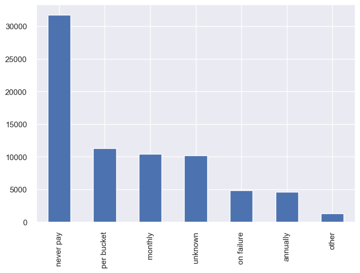

```python
dataFE['payment_type'].value_counts().plot(kind = 'bar')
```

##### water_quality, quality_group

Vamos a sacar los valores únicos.

```python
dataFE.loc[:,['water_quality', 'quality_group']].nunique()
```

```
water_quality    8
quality_group    6
dtype: int64
```

```python
dataFE.loc[:,['water_quality', 'quality_group']].value_counts()
```

```
water_quality       quality_group
soft                good             63505
salty               salty             6082
unknown             unknown           2345
milky               milky             1005
coloured            colored            623
salty abandoned     salty              423
fluoride            fluoride           244
fluoride abandoned  fluoride            23
dtype: int64
```

Me quedo con water_quality ya que tiene información más precisa de las aguas. De la misma forma, hay unknown en la variable. De la misma forma que lo anterior, puede ser información útil tenerla de esta forma, ya que a lo mejor es la calidad del agua que no se rija por las otras categorías.

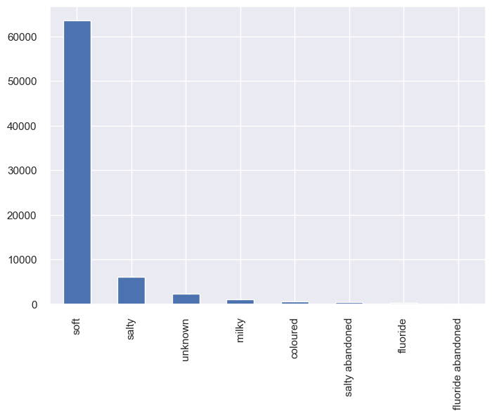

```python
dataFE['water_quality'].value_counts().plot(kind = 'bar')
```

```python
dataFE.drop('quality_group', axis = 1, inplace = True)
```

##### quantity, quantity_group

Sacamos los valores únicos.

```python
dataFE.loc[:,['quantity', 'quantity_group']].nunique()
```

```
quantity          5
quantity_group    5
dtype: int64
```

```python
dataFE.loc[:,['quantity', 'quantity_group']].value_counts()
```

```
quantity      quantity_group
enough        enough            41522
insufficient  insufficient      18896
dry           dry                7782
seasonal      seasonal           5075
unknown       unknown             975
dtype: int64
```

Variable totalmente repetida, me quedo con quantity. De la misma forma, no imputo los unknown de la categoría.

```python
dataFE.drop('quantity_group', axis = 1, inplace = True)
dataFE['quantity'].value_counts()
```

```
enough          41522
insufficient    18896
dry              7782
seasonal         5075
unknown           975
Name: quantity, dtype: int64
```

##### source, source_type, source_class

Sacamos los valores únicos.

```python
dataFE.loc[:,['source', 'source_type', 'source_class']].nunique()
```

```
source          10
source_type      7
source_class     3
dtype: int64
```

```python
dataFE.loc[:,['source', 'source_type', 'source_class']].value_counts()
```

```
source                source_type           source_class
spring                spring                groundwater     21216
shallow well          shallow well          groundwater     21140
machine dbh           borehole              groundwater     13822
river                 river/lake            surface         11964
rainwater harvesting  rainwater harvesting  surface          2863
hand dtw              borehole              groundwater      1108
lake                  river/lake            surface           950
dam                   dam                   surface           840
other                 other                 unknown           261
unknown               other                 unknown            86
dtype: int64
```

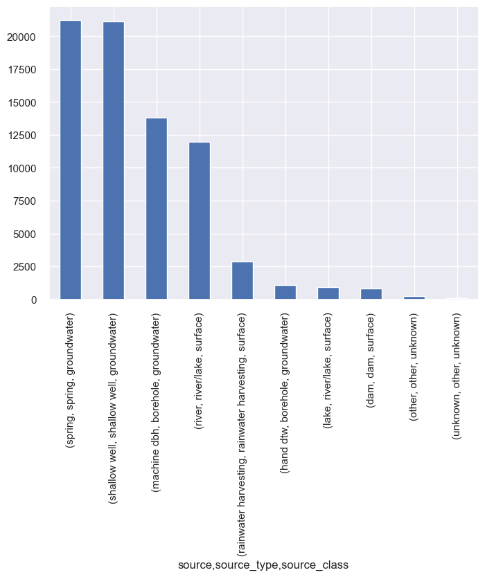

```python
dataFE.loc[:,['source', 'source_type', 'source_class']].value_counts().plot(kind = 'bar')
```

Voy a eliminar la variable source_type. Por definición de las variables son la fuente del agua. Prefiero quedarme con source debido a que tiene más categorías que source_type.

Veamos la gráfica después de eliminar la variable.

```python
dataFE.drop('source_type', axis = 1, inplace = True)
```

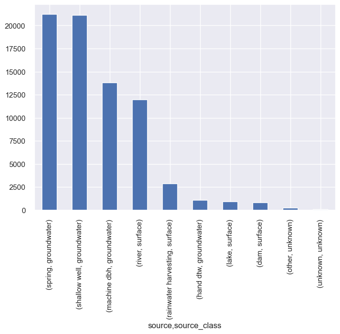

```python
dataFE.loc[:,['source', 'source_class']].value_counts().plot(kind = 'bar')
```

##### waterpoint_type, waterpoint_type_group

Saquemos los valores únicos.

```python
dataFE.loc[:,['waterpoint_type', 'waterpoint_type_group']].nunique()
```

```
waterpoint_type          7
waterpoint_type_group    6
dtype: int64
```

```python
dataFE.loc[:,['waterpoint_type', 'waterpoint_type_group']].value_counts()
```

```
waterpoint_type              waterpoint_type_group
communal standpipe           communal standpipe       35628
hand pump                    hand pump                21884
other                        other                     8010
communal standpipe multiple  communal standpipe        7611
improved spring              improved spring            959
cattle trough                cattle trough              150
dam                          dam                          8
dtype: int64
```

Me quedo con la variable 'waterpoint_type', ya que tiene categorías más precisas, y además, la otra variable es exactamente igual pero con una categoría menos. Procedo a eliminarla

```python
dataFE.drop('waterpoint_type_group', axis = 1, inplace = True)
```

##### funder e installer

Vemos los siguiente valores para las variables.

```python
dataFE[['funder', 'installer']].nunique()
```

```
funder       2140
installer    2410
dtype: int64
```

Que son muhcas categorías en ambas variables. Vamos a reducir el número de categorías donde imputaremos aquellas que sean más del 0.01% por su nombre, las demás como 'other' por seguir la mimsa terminología.

Para funder

```python
dataFE['funder'] = dataFE['funder'].str.lower()

fund = dataFE.groupby('funder')['id'].count().reset_index()
fund = fund.sort_values('id', ascending = False)
fund['porcentaje'] = (fund['id']/fund['id'].sum())*100
best = fund[fund['porcentaje'] > 0.01]

dataFE['funder'] = np.where(dataFE['funder'].isin(best['funder']), dataFE['funder'], 'other')
```

Para installer

```python
dataFE['installer'] = np.where(dataFE['installer']=='gove', 'gover', dataFE['installer'] )
dataFE['installer'] = np.where(dataFE['installer']=='community', 'commu', dataFE['installer'] )
dataFE['installer'] = np.where(dataFE['installer']=='danid', 'danida', dataFE['installer'] )


inst = dataFE.groupby('installer')['id'].count().reset_index()
inst = inst.sort_values('id', ascending = False)
inst['porcentaje'] = (inst['id']/inst['id'].sum())*100
best = inst[inst['porcentaje'] > 0.01]
```

```python
dataFE['installer'] = np.where(dataFE['installer'].isin(best['installer']), dataFE['installer'], 'other')
```

##### lga

Sacamos los valores.

```python
dataFE['lga'].unique()
```

```
['Ludewa', 'Serengeti', 'Simanjiro', 'Nanyumbu', 'Karagwe', ..., 'Ilemela', 'Kilindi', 'Arusha Urban', 'Songea Urban', 'Nyamagana']
Length: 125
Categories (125, object): ['Arusha Rural', 'Arusha Urban', 'Babati', 'Bagamoyo', ..., 'Ukerewe', 'Ulanga', 'Urambo', 'Uyui']
```

Vemos que para la variable lga tiene 125 categorías. Además, podemos ver que tiene, por ejemplo Arusha Rural y Arusha Urban. Además, las otras categorías son simples nombres, donde lo podemos poner como el valor de 'other' por seguir la terminología del conjunto de datos. Asi pues, donde ponga 'x Rural' se convierte solo a 'Rural' y de la misma forma con Urban.

```python
dataFE['lga'] = dataFE['lga'].apply(lambda x: 'rural' if x.endswith('Rural')
                        else ('urban' if x.endswith('Urban')
                              else 'other'))
```

```python
dataFE['lga'].unique()
```

```
array(['other', 'rural', 'urban'], dtype=object)
```

##### permit

Para permit, vamos a basarnos en imputaciones por la moda con la agrupación de public_meeting (Verdadero/Falso) y management_group que es quien gestiona el agua.

```python
permit_moda= dataFE.groupby(['public_meeting', 'management_group'])['permit'].agg(pd.Series.mode).reset_index()
permit_moda
```

|  | public_meeting | management_group | permit |
| --- | --- | --- | --- |
| 0 | False | commercial | True |
| 1 | False | other | True |
| 2 | False | parastatal | False |
| 3 | False | unknown | True |
| 4 | False | user-group | False |
| 5 | True | commercial | True |
| 6 | True | other | True |
| 7 | True | parastatal | True |
| 8 | True | unknown | True |
| 9 | True | user-group | True |

Vamos a realiza la imputación, mergeando con el dataframe original, donde si en permit hay NAN, se reemplará por la moda de public_meeting con managemente_group. Si en ello hay NAN, se imputará con la moda de permit.

```python
permit_moda = permit_moda.rename(columns={"permit": "imputed_permit_mg"})
dataFE = dataFE.merge(permit_moda, how = 'left', on = ['public_meeting', 'management_group'])

dataFE['imputed_permit'] = np.where(dataFE['permit'].isna(), dataFE['imputed_permit_mg'], dataFE['permit'])
dataFE['imputed_permit'] = np.where(dataFE['imputed_permit'] .isna(), dataFE['permit'].mode(), dataFE['imputed_permit'])

dataFE.drop(['permit', 'imputed_permit_mg'], axis=1, inplace = True)

dataFE.rename(columns={'imputed_permit': 'permit'}, inplace = True)
```

##### public_meeting

Vamos a imputar estos valores directamente por la moda.

```python
dataFE['public_meeting'] = dataFE['public_meeting'].fillna(dataFE['public_meeting'].mode()[0])
```

## Feature Engineering

Vamos a crear nuevas variables que estén relacionadas con variables del dataframe y podamos obtener mejor prediccion de la variable respuesta.

##### operating_year

Esta variable indicará el tiempo que lleva la bomba de agua operando, desde que se contruyó hasta que se registró en el conjunto de datos. Convertimos los valores que son ceros en construction_year

```python
dataFE.loc[dataFE.construction_year == 0, 'construction_year'] = np.nan

dataFE['operating_year'] = dataFE.apply(lambda x: x['Año'] - x['construction_year'], axis = 1)
```

Veamos su histograma.

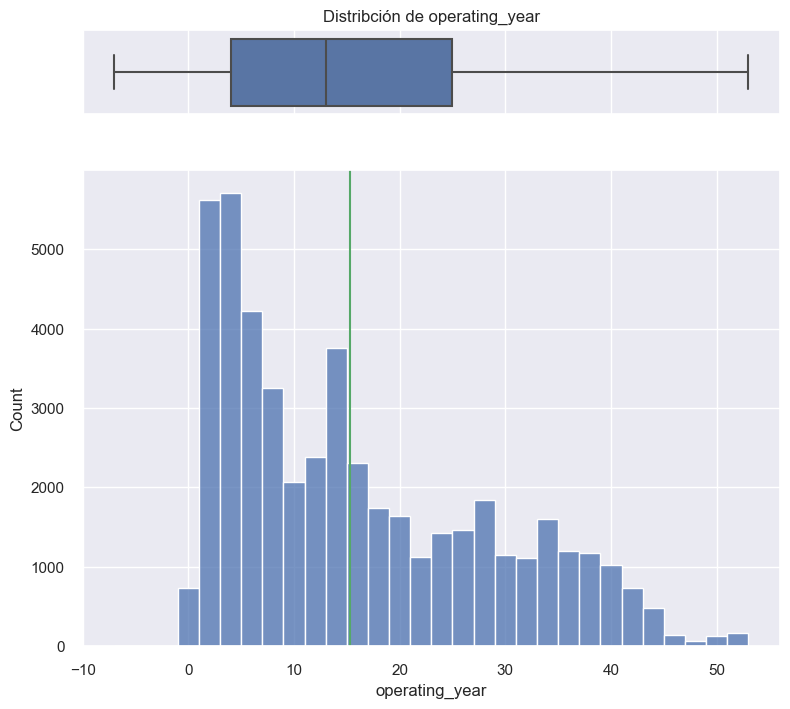

```python
histogram_boxplot(dataFE['operating_year'], bins = 30, font_scale=1, title="Distribción de operating_year")
```

Vamos asegurarnos que no tenemos valores negativos.

```python
dataFE[dataFE['operating_year'] < 0].head()
```

|  | id | amount_tsh | funder | gps_height | installer | longitude | latitude | wpt_name | num_private | basin | ... | source | source_class | waterpoint_type | status_group | tr-tst | Año | Mes | Dia | permit | operating_year |
| --- | --- | --- | --- | --- | --- | --- | --- | --- | --- | --- | --- | --- | --- | --- | --- | --- | --- | --- | --- | --- | --- |
| 8729 | 20198 | 0.0 | government of tanzania | 86 | DWE | 38.959776 | -5.247278 | Kwa Bi Shoga | 0 | Pangani | ... | shallow well | groundwater | hand pump | non functional | 0 | 2004 | 5 | 6 | True | -4.0 |
| 10441 | 55069 | 20.0 | plan int | 307 | DDCA | 38.768656 | -7.298419 | Mianzi Primary School | 0 | Rufiji | ... | spring | groundwater | hand pump | non functional | 0 | 2004 | 12 | 3 | False | -2.0 |
| 13366 | 48759 | 100.0 | other | 1331 | other | 34.290885 | -1.699609 | Maro Mgaya | 0 | Lake Victoria | ... | shallow well | groundwater | hand pump | functional | 0 | 2004 | 6 | 2 | True | -7.0 |
| 23373 | 20534 | 50.0 | other | 239 | other | 39.272736 | -11.019000 | Juhudi | 0 | Ruvuma / Southern Coast | ... | spring | groundwater | communal standpipe multiple | functional | 0 | 2004 | 3 | 1 | False | -5.0 |
| 27501 | 53086 | 500.0 | kkkt | 1611 | Villagers | 34.900561 | -8.873813 | Kwa Barnabasi Kilumile | 0 | Rufiji | ... | hand dtw | groundwater | hand pump | functional | 0 | 2004 | 1 | 3 | False | -5.0 |

5 rows × 38 columns

Donde si tenemos. Por tanto, convertimos a NANs estos valores e imputaremos sobre la media. Además, eliminamos las otras dos variables.

```python
dataFE.loc[dataFE.operating_year < 0, 'operating_year'] = np.nan
dataFE.drop(['Año', 'construction_year'], axis = 1, inplace = True)
```

##### weather

Vamos a crear una nueva variable que se llame weather, que nos indique por meses si es una temporada de lluvia o no en el propio país. Esta variable parte de la variable 'Mes'.

Definimos el mapeo del tiempo basándonos en esta web: https://itakasafaris.com/informacion-para-viajar-a-tanzania/como-ir-de-safari-a-tanzania/cuando-viajar-a-tanzania/#:~:text=Tanzania%20tiene%20un%20clima%20tropical,y%20diciembre%20(lluvias%20cortas).

```python
mapeo_temporada = {1: 'short dry',2:'short dry', 3: 'long rain', 4: 'long rain', 5: 'long rain',6: 'long dry',
                 7: 'long dry', 8: 'long dry', 9: 'long dry', 10: 'long dry', 11:'short rain', 12:'short rain'}

dataFE['Mes'] = dataFE['Mes'].replace(mapeo_temporada)

dataFE.drop('Mes', axis=1, inplace = True)
```

##### region, region_code, district_code

Vamos a unir las tres variables en una sola, que nos indique la localizacoin de la bomba de agua en una sola variable.

Convertimos region_code y districti_code a string; region a object, para poder realizar la unificación.

```python
dataFE['region'] = dataFE['region'].astype('object')
dataFE['region_code'] = dataFE['region_code'].astype('str')
dataFE['district_code'] = dataFE['district_code'].astype('str')
```

Unificamos y eliminamos las variables sobrantes.

```python
dataFE['region_district'] = dataFE['region']+ "-" +dataFE['region_code']+ "-" +dataFE['district_code']

dataFE.drop(['region', 'region_code', 'district_code'], axis = 1, inplace = True)
```

Realizamos la conversión de los nans de la numéricas.

```python
dataFE.loc[dataFE.longitude == 0, 'longitude'] =np.nan
dataFE.loc[dataFE.population == 0, 'population'] =np.nan
dataFE.loc[dataFE.gps_height <= 0, 'gps_height'] =np.nan
```

```python
dataFE.info()
```

```
<class 'pandas.core.frame.DataFrame'>
Int64Index: 74250 entries, 0 to 74249
Data columns (total 33 columns):
 #   Column                 Non-Null Count  Dtype
---  ------                 --------------  -----
 0   id                     74250 non-null  int64
 1   amount_tsh             74250 non-null  float64
 2   funder                 74250 non-null  object
 3   gps_height             46720 non-null  float64
 4   installer              74250 non-null  object
 5   longitude              71981 non-null  float64
 6   latitude               74250 non-null  float64
 7   wpt_name               74250 non-null  category
 8   num_private            74250 non-null  int64
 9   basin                  74250 non-null  category
```

[output cut: 25 more lines]

## Eliminación de variable

Variable que no aporta al modelo porque tiene un solo valor.

```python
dataFE.drop(['recorded_by'], axis = 1, inplace = True)
```

## Imputaciones

```python
varObj = dataFE.status_group
imputedData = dataFE.drop('status_group', axis = 1)
```

```python
# Moda
imputer_moda = skl_imp.SimpleImputer(strategy='most_frequent', missing_values=np.nan)
# Media
imputer_mean = fe_imp.MeanMedianImputer(imputation_method='mean')
```

Definimos las listas de variables numéricas y categóricas.

```python
imput_cont = imputedData.select_dtypes(include=np.number)
imput_cat = imputedData.select_dtypes(exclude=np.number)
```

Realizamos imputaciones sobre las variables numéricas a partir de la media, moda para categóricas.

```python
# Media
datos_mean_imputed = imputer_mean.fit(imput_cont).transform(imput_cont)
# Moda
imput_moda_imputed = pd.DataFrame(imputer_moda.fit_transform(imput_cat),columns=imput_cat.columns)
```

Unimos los dos conjunto de datos ya imputados y lo guardamos en el dataframe 'data_imputed', para que más adelante podamos utilizar el dataframe 'data' sin ningún problema. Además, introducimos la variable objetivo y comprobamos que sigue teniendo los nans que queremos.

```python
data_imputed = pd.concat([datos_mean_imputed,imput_moda_imputed], axis = 1)
data_imputed['status_group'] = varObj
```

Ya tenemos nuestro conjunto de datos listo para entrenar los modelos.

Se observa que después de las imputaciones sobre las variables categóricas, éstas se convierten a tipo 'object', donde realizamos una conversión a 'category'.

```python
listObjec = data_imputed.columns[data_imputed.dtypes == 'object'].tolist()

for col in listObjec:
    data_imputed[col] = data_imputed[col].astype('category')
```

Vamos a realizar una copia del dataset para realizar otras pruebas, como son el escalado de datos de las numéricas y balanceo de los datos.

```python
data_escalado = data_imputed.copy()
data_dummies = data_imputed.copy()
```

```python
data_dummies.head()
```

|  | id | amount_tsh | gps_height | longitude | latitude | num_private | population | tr-tst | Dia | operating_year | ... | management_group | payment_type | water_quality | quantity | source | source_class | waterpoint_type | permit | region_district | status_group |
| --- | --- | --- | --- | --- | --- | --- | --- | --- | --- | --- | --- | --- | --- | --- | --- | --- | --- | --- | --- | --- | --- |
| 0 | 69572 | 6000.0 | 1390.000000 | 34.938093 | -9.856322 | 0 | 109.000000 | 0 | 1 | 12.000000 | ... | user-group | annually | soft | enough | spring | groundwater | communal standpipe | False | Iringa-11-5 | functional |
| 1 | 8776 | 0.0 | 1399.000000 | 34.698766 | -2.147466 | 0 | 280.000000 | 0 | 3 | 3.000000 | ... | user-group | never pay | soft | insufficient | rainwater harvesting | surface | communal standpipe | True | Mara-20-2 | functional |
| 2 | 34310 | 25.0 | 686.000000 | 37.460664 | -3.821329 | 0 | 250.000000 | 0 | 1 | 4.000000 | ... | user-group | per bucket | soft | enough | dam | surface | communal standpipe multiple | True | Manyara-21-4 | functional |
| 3 | 67743 | 0.0 | 263.000000 | 38.486161 | -11.155298 | 0 | 58.000000 | 0 | 1 | 27.000000 | ... | user-group | never pay | soft | dry | machine dbh | groundwater | communal standpipe multiple | True | Mtwara-90-63 | non functional |
| 4 | 19728 | 0.0 | 1058.722303 | 31.130847 | -1.825359 | 0 | 283.042623 | 0 | 3 | 15.300441 | ... | other | never pay | soft | seasonal | rainwater harvesting | surface | communal standpipe | True | Kagera-18-1 | functional |

5 rows × 32 columns

## Conversión de las categorías a numéricas categóricas

En este apartado vamos a tranformar las variables categóricas en variables de tipo entero, que seguirán siendo categorías pero de valor entero para que los modelos que vamos a introducir tengan mejor interpretabilidad de las variables.

Hacemos uso de la función LabelEncoder()

```python
cols = data_imputed.columns[data_imputed.dtypes == 'category'].tolist()

for col in cols:
    le = LabelEncoder()
    data_imputed[col] = le.fit_transform(data_imputed[col])

data_imputed.head()
```

Donde dicha conversión a la variable respuesta se le ha dado los siguiente valores enteros a las categorías:

- 0 -> functional
- 1 -> functional needs repair
- 2 -> non functional

También le habrá dado a los valores NANs de la variable respuesta, con valor 3. Realizaremos su conversión nuevamente.

```python
data_imputed[data_imputed['status_group'] == 3].head()
```

Además, viendo la información de las variables, vamos a realizar la conversión de flotante a entero de las siguiente variables:

```python
data_imputed['population'] = data_imputed['population'].astype('int64')
data_imputed['operating_year'] = data_imputed['operating_year'].astype('int64')
```

## Construir el dataset train y test. Accuracy de modelos.

Antes de nada, tendremos que separar los dos conjuntos de datos de nuestro dataframe, en el training que será el que se introducirá en el modelo para que aprenda, y el test que será donde realizaremos las predicciones y lo meteremos en la página web para ver el accuracy que obtenemos.

```python
training = data_imputed[data_imputed['tr-tst'] == 0].copy()
training.drop('tr-tst', axis = 1, inplace = True)
test = data_imputed[data_imputed['tr-tst'] == 1].copy()
test.drop('tr-tst', axis = 1, inplace = True)
test['status_group'] = np.nan
```

Saquemos los dos conjuntos de datos y observamos que tenmos los datos bien separados.

```python
test.head()
```

```python
training.head()
```

Prodecemos a crear los conjuntos de datos train y test a partir del dataframe training. Realizaremos un muestreo estratificado en función de la variable respuesta para que en los splits sus categorías estén bien representadas. El split a utilizar será un 80/20, training/test, respectivamente.

```python
X_train, X_test, y_train, y_test = train_test_split(training.drop('status_group', axis=1),
                                                     training.status_group,
                                                     test_size = 0.2,
                                                     random_state = 1234,
                                                     stratify = training.status_group)
```

Vamos a realizar una comparación de los siguientes modelos.

- **Extra Trees Classifier**
- **DecisionTreeClassifier**
- **Random Forest Classifier**

##### Random Forest Classifier

```python
model1 = RandomForestClassifier(random_state = 1234).fit(X_train, y_train)
y_pred = model1.predict(X_test)
accuracy_score(y_pred, y_test)
```

[output not shown]

##### DecisionTreeClassifier

```python
model2 = DecisionTreeClassifier(random_state = 1234).fit(X_train, y_train)
y_pred = model2.predict(X_test)
accuracy_score(y_pred, y_test)
```

[output not shown]

##### Extra Trees Classifier

```python
model3 = ExtraTreesClassifier(random_state = 1234).fit(X_train, y_train)
y_pred = model3.predict(X_test)
accuracy_score(y_pred, y_test)
```

[output not shown]

Donde obtenemos que el mejor modelo es el Random Forest Classifier, mejorando en dimensionalidad de categorías y número de variables, donde antes teniamos un 0.8123 de accuracy con modelo completo y ahora un 0.8127 con una gran reducción en las variables predictoras.

Vamos aplicar validación cruzada repetida para asegurarnos que el score del accuracy es el que queremos, en torno a 0.80 - 0.81. Además, vamos pintar un gráfico de bigotes. Vamos aplicar una validación cruzada de 5 particiones sobre el conjunto de datos.

```python
models_rcv = {
    "RF": RandomForestClassifier(random_state = 1234)
}

results, names = rskf_comparison(models_rcv, X_train, y_train)
plt.figure(figsize=(10, 6))
comparison = plt.boxplot(results)
plt.xticks(np.arange(1,len(names)+1),names)
plt.show(comparison)
```

[output not shown]

Donde vemos qe la salida es la esperada, obteniendo un accuracy de 0.80905, que indica que el modelo no variará mucho a la hora de predecir.

Vamos a sacar para este modelo, los accuracy de train y test, así como la matriz de confusión.

```python
#score model
best_model = RandomForestClassifier(random_state = 1234)

#fit and predict
best_model.fit(X_train, y_train)
y_pred = best_model.predict(X_test)
y_pred_train = best_model.predict(X_train)

#print best model scores on test data
print("Accuracy score train: {}".format(accuracy_score(y_train, y_pred_train)))
print("Accuracy score test: {}".format(accuracy_score(y_test, y_pred)))
print()

#print(confusion_matrix(y_test, y_pred))
print(classification_report(y_test, y_pred))

confusion_matrix_plotter(y_test, y_pred)

feature_importances(best_model, " Random forest classifier")
```

[output not shown]

Obtenemos buenas métricas en el modelo que hemos sacado. Observamos de precision un 0.80 y 0.86 para los casos de funcionales y no funcionales, que es alta para los datos que tenemos. Hay muy buen recall para el caso de las bombas de agua funcionales, así como el f1-score.

Del mismo modo, la matriz de confusión, nos da una información sobre los valores que nuestro modelo está acertando en función de los que se sabe cuales son. Es normal la confusión a la hora de predecir los no funcionales, pues se tiene casi mismos registros.

Por último, observamos que las variables más importantes son quantity, longitude y latitude.

Observamos que hay mejora de los modelos, y donde el mejor es el RandomForestClassifier que se obtiene un accuracy de 0.8127, en comparación con de 0.8123.

## Tunning hiperparámetros

Vamos a buscar los mejores parámetros para el mejor modelo que nos ha dado anteriormente.

Definimos todos los parámetros que queremos mejorar

```python
### Tuneo de hiperparámetros
grid_param = {
    'n_estimators': [100, 150, 200, 250],
    'criterion': ['gini', 'entropy'],
    'max_depth': [20,25,30],
}
```

Definimos el modelo y el GridSearchCV

```python
modelo = RandomForestClassifier(random_state = 1234)

model_grid = GridSearchCV(estimator=modelo,
                     param_grid=grid_param,
                     scoring='accuracy',
                     cv=5,
                     n_jobs=-1)
```

Realizamos la búsqueda del mejor modelo.

```python
model_grid.fit(X_train, y_train)
```

Sacamos el mejor score, sus parámetros y el mejor modelo.

```python
print('Best Score:', model_grid.best_score_)
print('Parameters:', model_grid.best_params_)
print('Best Model:', model_grid.best_estimator_)
```

[output not shown]

Vemos que obtenemos el mejor modelo con esos parámetros:

- criterion: gini,
- max_depth: 25,
- n_estimators': 200

Vamos a sacar un modelo del random forest para obtener el accuracy, así como la matriz de confunsión.

```python
#score model
best_model = RandomForestClassifier(random_state = 1234, criterion = 'gini', max_depth = 25, n_estimators = 200)

#fit and predict
best_model.fit(X_train, y_train)
y_pred = best_model.predict(X_test)
y_pred_train = best_model.predict(X_train)

#print best model scores on test data
print("Accuracy score train: {}".format(accuracy_score(y_train, y_pred_train)))
print("Accuracy score test: {}".format(accuracy_score(y_test, y_pred)))
print()

#print(confusion_matrix(y_test, y_pred))
print(classification_report(y_test, y_pred))

confusion_matrix_plotter(y_test, y_pred)

feature_importances(best_model, " Random forest classifier")
```

[output not shown]

Obtenemos buenas métricas en el modelo que hemos sacado. Observamos de precision un 0.80 y 0.86 para los casos de funcionales y no funcionales, que es alta para los datos que tenemos. Hay muy buen recall para el caso de las bombas de agua funcionales, así como el f1-score.

Del mismo modo, la matriz de confusión, nos da una información sobre los valores que nuestro modelo está acertando en función de los que se sabe cuales son. Es normal la confusión a la hora de predecir los no funcionales, pues se tiene casi mismos registros. Obtenemos un accuracy de 0.8134, mejorando el anterior con valor 0.8127.

Lo que haría falta es más información acerca de las bombas que tienen como valor 'functional need repair'.

Por último, observamos que las variables más importantes son quantity, longitude y latitude.

Por otra parte, realizamos la predicción del conjunto test. Creamos un dataset con los 'id' del test.

```python
modelo = pd.DataFrame(test['id'])
modelo.head()
```

Realizamos la predicción a partir del modelo que hemos definido en el RandomForestClassifier llamado 'classifier'

```python
modelo_proba = best_model.predict(test.drop('status_group', axis = 1))
modelo_proba = pd.DataFrame(modelo_proba,columns=['status_group'], index = test.index)
modelo_proba.head()
```

Lo guardamos en la predicción del dataframe y realizamos la conversión de los números enteros por los valores que les corresponde, como hemos visto antes con la función LabelEncoder():

- 0 -> functional
- 1 -> functional needs repair
- 2 -> non functional

```python
modelo['status_group'] = modelo_proba['status_group']
```

```python
modelo.loc[modelo.status_group == 0, 'status_group'] = 'functional'
modelo.loc[modelo.status_group == 1, 'status_group'] = 'functional needs repair'
modelo.loc[modelo.status_group == 2, 'status_group'] = 'non functional'
modelo.head()
```

Ya tenemos dicha la predicción. Vamos a guardarlo en un archivo csv para subirlo en la página web drivendata Pump it Up: Data Mining the Water Table, veamos que accuracy obtenemos ahí.

```python
modelo.to_csv('predicción2.csv', index = False)
```

Obtenemos un accuracy de: 0.8160.

[figure not shown]

## Escalado de datos

Vamos aplicar un escalado de datos a las variables numéricas. Debido por ejemplo, a la diferencia entre los años operativos, 'operating_year' y las longitudes, latitudes.

Separamos numéricas y categóricas.

```python
imput_cont = data_escalado.select_dtypes(include=np.number)
imput_cat = data_escalado.select_dtypes(exclude=np.number)
```

Guardamos en el dataframe aux, las variables que vamos a escalar que son:

- 'amount_tsh', 'gps_height', 'longitude', 'latitude', 'population', 'operating_year'.

```python
aux = imput_cont[['amount_tsh', 'gps_height', 'longitude', 'latitude', 'population', 'operating_year']]
imput_cont.drop(['amount_tsh', 'gps_height', 'longitude', 'latitude', 'population', 'operating_year'], axis = 1, inplace = True)
aux.head()
```

Realizamos el escalado. Lo guardamos en el dataframe de data_imputed.

```python
data_imputed_scaled = pd.DataFrame(scale(aux))
data_imputed_scaled.columns = ['amount_tsh', 'gps_height', 'longitude', 'latitude', 'population', 'operating_year']


data_imputed = pd.concat([imput_cont,data_imputed_scaled,imput_cat], axis = 1)
data_imputed['status_group'] = varObj

data_imputed.head()
```

Aplicamos LabelEncoder para las variables categóricas.

```python
cols = data_imputed.columns[data_imputed.dtypes == 'category'].tolist()

for col in cols:
    le = LabelEncoder()
    data_imputed[col] = le.fit_transform(data_imputed[col])

data_imputed.head()
```

Donde dicha conversión a la variable respuesta se le ha dado los siguiente valores enteros a las categorías:

- 0 -> functional
- 1 -> functional needs repair
- 2 -> non functional

Además, viendo la información de las variables, vamos a realizar la conversión de flotante a entero de las siguiente variables:

```python
data_imputed['population'] = data_imputed['population'].astype('int64')
data_imputed['operating_year'] = data_imputed['operating_year'].astype('int64')
```

Hacemos separación de training y test.

```python
training = data_imputed[data_imputed['tr-tst'] == 0].copy()
training.drop('tr-tst', axis = 1, inplace = True)
test = data_imputed[data_imputed['tr-tst'] == 1].copy()
test.drop('tr-tst', axis = 1, inplace = True)
test['status_group'] = np.nan
```

Prodecemos a crear los conjuntos de datos train y test a partir del dataframe training. Realizaremos un muestreo estratificado en función de la variable respuesta para que en los splits sus categorías estén bien representadas. El split a utilizar será un 80/20, training/test, respectivamente.

```python
X_train, X_test, y_train, y_test = train_test_split(training.drop('status_group', axis=1),
                                                     training.status_group,
                                                     test_size = 0.2,
                                                     random_state = 1234,
                                                     stratify = training.status_group)
```

Vamos a realizar una comparación de los siguientes modelos, algunos de ellos nos los dió pycaret.

- **Extra Trees Classifier**
- **DecisionTreeClassifier**
- **Random Forest Classifier**

##### Random Forest Classifier

```python
model1 = RandomForestClassifier(random_state = 1234).fit(X_train, y_train)
y_pred = model1.predict(X_test)
accuracy_score(y_pred, y_test)
```

[output not shown]

##### DecisionTreeClassifier

```python
model2 = DecisionTreeClassifier(random_state = 1234).fit(X_train, y_train)
y_pred = model2.predict(X_test)
accuracy_score(y_pred, y_test)
```

[output not shown]

##### Extra Trees Classifier

```python
model3 = ExtraTreesClassifier(random_state = 1234).fit(X_train, y_train)
y_pred = model3.predict(X_test)
accuracy_score(y_pred, y_test)
```

[output not shown]

Donde obtenemos que el mejor modelo es el Random Forest Classifier con un accuracy de 0.8077, peor el caso anterior.

Vamos aplicar validación cruzada repetida para asegurarnos que el score del accuracy es el que queremos, en torno a 0.80 - 0.81. Además, vamos pintar un gráfico de bigotes. Vamos aplicar una validación cruzada de 5 particiones sobre el conjunto de datos.

```python
models_rcv = {
    "RF": RandomForestClassifier(random_state = 1234)
}

results, names = rskf_comparison(models_rcv, X_train, y_train)
plt.figure(figsize=(10, 6))
comparison = plt.boxplot(results)
plt.xticks(np.arange(1,len(names)+1),names)
plt.show(comparison)
```

[output not shown]

Donde vemos qe la salida es la esperada, obteniendo un accuracy de 0.80905, que indica que el modelo no variará mucho a la hora de predecir.

Vamos a sacar para este modelo, los accuracy de train y test, así como la matriz de confusión.

```python
#score model
best_model = RandomForestClassifier(random_state = 1234)

#fit and predict
best_model.fit(X_train, y_train)
y_pred = best_model.predict(X_test)
y_pred_train = best_model.predict(X_train)

#print best model scores on test data
print("Accuracy score train: {}".format(accuracy_score(y_train, y_pred_train)))
print("Accuracy score test: {}".format(accuracy_score(y_test, y_pred)))
print()

#print(confusion_matrix(y_test, y_pred))
print(classification_report(y_test, y_pred))

confusion_matrix_plotter(y_test, y_pred)

feature_importances(best_model, " Random forest classifier")
```

[output not shown]

Obtenemos buenas métricas en el modelo que hemos sacado. Observamos de precision un 0.80 y 0.85 para los casos de funcionales y no funcionales, que es alta para los datos que tenemos. Hay muy buen recall para el caso de las bombas de agua funcionales, así como el f1-score.

Del mismo modo, la matriz de confusión, nos da una información sobre los valores que nuestro modelo está acertando en función de los que se sabe cuales son. Es normal la confusión a la hora de predecir los no funcionales, pues se tiene casi mismos registros. Obtenemos un accuracy de 0.8077, del cual emperora con el anterior con valor 0.8127 (sin el tuneo de hiperparametros).

Lo que haría falta es más información acerca de las bombas que tienen como valor 'functional need repair'.

Por último, observamos que las variables más importantes son quantity, longitude y latitude.

Por otra parte, realizamos la predicción del conjunto test. Creamos un dataset con los 'id' del test.

```python
modelo = pd.DataFrame(test['id'])
modelo.head()
```

Realizamos la predicción a partir del modelo que hemos definido en el RandomForestClassifier llamado 'classifier'

```python
modelo_proba = best_model.predict(test.drop('status_group', axis = 1))
modelo_proba = pd.DataFrame(modelo_proba,columns=['status_group'], index = test.index)
modelo_proba.head()
```

Lo guardamos en la predicción del dataframe y realizamos la conversión de los números enteros por los valores que les corresponde, como hemos visto antes con la función LabelEncoder():

- 0 -> functional
- 1 -> functional needs repair
- 2 -> non functional

```python
modelo['status_group'] = modelo_proba['status_group']
```

```python
modelo.loc[modelo.status_group == 0, 'status_group'] = 'functional'
modelo.loc[modelo.status_group == 1, 'status_group'] = 'functional needs repair'
modelo.loc[modelo.status_group == 2, 'status_group'] = 'non functional'
modelo.head()
```

Ya tenemos dicha la predicción. Vamos a guardarlo en un archivo csv para subirlo en la página web drivendata Pump it Up: Data Mining the Water Table, veamos que accuracy obtenemos ahí.

```python
modelo.to_csv('predicción3.csv', index = False)
```

Obtenemos un accuracy de: 0.8115. Era normal que bajara pues habia salido un accuracy peor.

[figure not shown]

## Balanceo de datos

Observamos que hay un gran desbalanceo de los datos, donde el valor de la variable respuesta 'functional needs repair' tiene menos información que el resto.

- 0 -> functional
- 1 -> functional needs repair
- 2 -> non functional

```python
training.status_group.value_counts()
```

```python
print("Before OverSampling, counts of label '0': {}".format(sum(training.status_group==0)))
print("Before OverSampling, counts of label '1': {}".format(sum(training.status_group==1)))
print("Before OverSampling, counts of label '2': {} \n".format(sum(training.status_group==2)))
```

Vamos a subir la variable que menor registros tiene a 25000, para así eliminar dicho desbalanceo. Para ello, realizamos lo siguiente:

```python
sm = SMOTE(random_state=2,sampling_strategy={1:25000})
x, y = sm.fit_resample(training.drop('status_group',axis=1), training.status_group)

y.value_counts().plot.pie(autopct="%.2f")
```

[output not shown]

Por tanto, obtenemos lo siguiente:

```python
print('After OverSampling, the shape of train_X: {}'.format(x.shape))
print('After OverSampling, the shape of train_y: {} \n'.format(y.shape))

print("After OverSampling, counts of label '0': {}".format(sum(y==0)))
print("After OverSampling, counts of label '1': {}".format(sum(y==1)))
print("After OverSampling, counts of label '2': {}".format(sum(y==2)))
```

- 0 -> functional -> 32259
- 1 -> functional needs repair -> 25000
- 2 -> non functional -> 22824

Vamos a realizar la partición training test con split del 20%.

```python
X_train, X_test, y_train, y_test = train_test_split(x,
                                                    y,
                                                    test_size=0.2,
                                                    random_state=42,
                                                    stratify = y)
```

```python
#score model
best_model = RandomForestClassifier(random_state = 1234)

#fit and predict
best_model.fit(X_train, y_train)
y_pred = best_model.predict(X_test)
y_pred_train = best_model.predict(X_train)

#print best model scores on test data
print("Accuracy score train: {}".format(accuracy_score(y_train, y_pred_train)))
print("Accuracy score test: {}".format(accuracy_score(y_test, y_pred)))
print()

#print(confusion_matrix(y_test, y_pred))
print(classification_report(y_test, y_pred))

confusion_matrix_plotter(y_test, y_pred)

feature_importances(best_model, " Random forest classifier")
```

[output not shown]

Obtenemos buenas métricas en el modelo que hemos sacado. Observamos de precision un 0.81 y 0.85 para los casos de funcionales y no funcionales, que es alta para los datos que tenemos. Hay muy buen recall para el caso de las bombas de agua funcionales, así como el f1-score. Es obvio, que para los 'functional needs repair' tenga mejor métrica por el ajuste que hemos hecho.

Del mismo modo, la matriz de confusión, nos da una información sobre los valores que nuestro modelo está acertando en función de los que se sabe cuales son. Es normal la confusión a la hora de predecir los no funcionales, pues se tiene casi mismos registros.

Por último, observamos que las variables más importantes son quantity, longitude y latitude.

Observamos que hay mejora de los modelos, y donde el mejor es el RandomForestClassifier que se obtiene un accuracy de 0.8556, en comparación con el mejor de la página web de 0.816.

Por otra parte, realizamos la predicción del conjunto test. Creamos un dataset con los 'id' del test.

```python
modelo = pd.DataFrame(test['id'])
modelo.head()
```

Realizamos la predicción a partir del modelo que hemos definido en el RandomForestClassifier llamado 'classifier'

```python
modelo_proba = best_model.predict(test.drop('status_group', axis = 1))
modelo_proba = pd.DataFrame(modelo_proba,columns=['status_group'], index = test.index)
modelo_proba.head()
```

Lo guardamos en la predicción del dataframe y realizamos la conversión de los números enteros por los valores que les corresponde, como hemos visto antes con la función LabelEncoder():

- 0 -> functional
- 1 -> functional needs repair
- 2 -> non functional

```python
modelo['status_group'] = modelo_proba['status_group']
```

```python
modelo.loc[modelo.status_group == 0, 'status_group'] = 'functional'
modelo.loc[modelo.status_group == 1, 'status_group'] = 'functional needs repair'
modelo.loc[modelo.status_group == 2, 'status_group'] = 'non functional'
modelo.head()
```

Ya tenemos dicha la predicción. Vamos a guardarlo en un archivo csv para subirlo en la página web drivendata Pump it Up: Data Mining the Water Table, veamos que accuracy obtenemos ahí.

```python
modelo.to_csv('predicción4.csv', index = False)
```

Obtenemos un accuracy de: 0.3115.

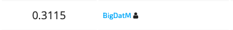

Era obvio que ibamos a obtener dicho score debido a que nos hemos inventado muchisimos registros para un valor. Por tanto, como mejora sería obtener más registros para los casos de 'functional needs repair'.

## PYCARET

Definimos el modelo sobre el conjunto de datos entrenamiento 'dt' que contiene solo labels y values.

```python
model_setup = setup(data=dt, target='status_group', session_id=1)
```

Veamos los modelos que se van a comparar.

```python
models()
```

Apliquemos la comparación de modelo.

```python
best_models = compare_models()
```

## Sleccion de variables con dummies

```python
data_dummies.info()
```

```
<class 'pandas.core.frame.DataFrame'>
Int64Index: 74250 entries, 0 to 74249
Data columns (total 32 columns):
 #   Column                 Non-Null Count  Dtype
---  ------                 --------------  -----
 0   id                     74250 non-null  int64
 1   amount_tsh             74250 non-null  float64
 2   gps_height             74250 non-null  float64
 3   longitude              74250 non-null  float64
 4   latitude               74250 non-null  float64
 5   num_private            74250 non-null  int64
 6   population             74250 non-null  float64
 7   tr-tst                 74250 non-null  int64
 8   Dia                    74250 non-null  int64
 9   operating_year         74250 non-null  float64
```

[output cut: 24 more lines]

```python
listaCat = data_dummies.select_dtypes(include=['object','category']).columns

#variables_binarias = variables_dummies[['permit', 'public_meeting']]

#variables_dummies.drop(['permit', 'public_meeting'], axis = 1, inplace = True)
```

```python
listaCont = data_dummies.select_dtypes(exclude=['object','category']).columns
```

```python
variables_dummies = data_dummies[listaCat]

variables_binarias = variables_dummies[['permit', 'public_meeting']]

variables_dummies.drop(['permit', 'public_meeting'], axis = 1, inplace = True)
```

```python
varObjCont = variables_dummies.status_group
variables_dummies.drop('status_group', axis = 1, inplace = True)
```

```python
dataD = data_dummies[listaCont]
dataD['amount_tsh'] = dataD['amount_tsh'].astype('int64')
dataD['population'] = dataD['population'].astype('int64')
dataD['operating_year'] = dataD['operating_year'].astype('int64')
```

```python
listaCat1 = listaCat.drop(['permit', 'public_meeting', 'status_group'])
listaCat1
```

```
Index(['funder', 'installer', 'wpt_name', 'basin', 'subvillage', 'lga', 'ward',
       'scheme_management', 'extraction_type', 'extraction_type_class',
       'management', 'management_group', 'payment_type', 'water_quality',
       'quantity', 'source', 'source_class', 'waterpoint_type',
       'region_district'],
      dtype='object')
```

```python
for k in listaCat1:
    dummies = pd.get_dummies(variables_dummies[k],prefix=k)
    dataD = pd.concat([dataD, dummies], axis=1)
    #dataD.drop(k, axis=1, inplace=True)
```

```python
for j in variables_binarias:
    dataD[j] = [1 if x == True else 0 for x in data[j]]
```

```python
import statsmodels.api as sm
dataD=sm.add_constant(dataD)
```

```python
from sklearn.linear_model import LinearRegression
from mlxtend.feature_selection import SequentialFeatureSelector as sfs

clf = RandomForestClassifier()
```

```python
# Definir el selector de variables
sfs_back = sfs(clf,k_features = 'best',forward=False,floating=False, scoring='accuracy',cv=2)
```

```python
# Ajustar a los datos
sfs_back = sfs_back.fit(dataD, varObjCont)

#print(sfs1.subsets_)
```

```python
# Ver nombres de variables seleccionadas
print(sfs_back.k_feature_names_)
```

```python
# Score po cv
sfs_back.k_score_
```